# Version-contingent fire danger trends in the Okanagan basin

What the 2025 update to the Canadian Forest Fire Weather Index System does to a trend estimate

Author

Seamus Murphy

Published

October 12, 2026

# 1 Introduction

British Columbia recorded the most severe wildfire seasons of its last century within the past two decades. In 2003 lightning and human causes produced more than 2,500 wildfire starts in the Interior, 334 homes were destroyed and more than 45,000 people were evacuated (Filmon, 2004, p. 10), after southern British Columbia had gone through “its driest three-year period on record” (Filmon, 2004, p. 17). In 2017 more than 1.2 million hectares burned, about 65,000 people were displaced, suppression cost more than 568 million dollars and the provincial state of emergency lasted 70 days, the first declared since 2003 (Abbott & Chapman, 2018, p. 25), and Kirchmeier-Young, Gillett, Zwiers, Cannon, & Anslow (2019) found that human-induced climate change had made the fire weather and fire behaviour metrics of that season 2 to 4 times more likely and had increased the area burned by a factor of 7 to 11. More than 1.2 million hectares burned again in 2018 (Hessburg et al., 2019, p. 7), the heat dome of late June 2021 accounted for 21 to 34 per cent of the area burned in North America that year, including 0.7 million hectares in British Columbia (Jain, Sharma, Acuna, Abatzoglou, & Flannigan, 2024), and the 2023 Canadian season burned about 15 million hectares under May to October temperatures 2.2 °C above the 1991 to 2020 average (Jain, Barber, et al., 2024). Parisien et al. (2023) placed four of the most severe British Columbia seasons of the last century in 2017, 2018, 2021 and 2023.

Those seasons followed a century in which burning had declined, and the historical record names several triggers for both the decline and the reversal. Tree-ring studies of the province’s dry forests reconstructed the regime before suppression. In Douglas-fir and ponderosa pine forests of the southern interior, Heyerdahl, Lertzman, & Wong (2012) found a mean plot-composite fire scar interval of 21 years from 1700 to 1900 and a mixed-severity regime at 66 per cent of plots, and in central British Columbia Brookes, Daniels, Copes-Gerbitz, Baron, & Carroll (2021) found that 23 fires between 1619 and 1943 burned at intervals of 10 to 30 years, whereas current fire-free intervals of 70 to 180 years exceed the historical maximum. Drought was the trigger those records share. Chavardès et al. (2021) found that below-average precipitation and summer drought synchronised fires across 14 dry-forest study areas of the Montane Cordillera from 1746 to 1945, and Harvey & Smith (2017) found in west central British Columbia from 1600 to 1900 that drought increasingly synchronised fire from local to regional scales while the El Niño Southern Oscillation, the Pacific Decadal Oscillation and the Pacific North American pattern had a weak or inconsistent influence, except in years when the first two were both positive. People were a second trigger, acting in both directions. At Ne Sextsine in T’exelc territory, Copes‐Gerbitz, Daniels, & Hagerman (2022) found that high fire frequency in low-severity plots ceased in the 1870s, following the smallpox epidemic, forced relocation to reserves and the prohibition of Indigenous burning, and Copes-Gerbitz, Hagerman, & Daniels (2022) traced five eras of provincial fire governance in which government decision-making superseded First Nations fire governance from the 1870s onward. Chavardès et al. (2021) attributed the fall in fire occurrence and synchrony after 1945 to fire exclusion, suppression and climatic variation.

The instrumental record showed the same decline and then its end. Meyn, Schmidtlein, et al. (2010) found that annual wildfire extent and occurrence across 16 landscape regions of British Columbia fell from 1920 to 2000 and that the fall was significantly related to wetter summers, and Meyn, Taylor, Flannigan, Thonicke, & Cramer (2010) found that year-to-year fire variability in the province’s biogeoclimatic zones over the same period was better related to summer drought than to climate oscillations. Parisien et al. (2023), analysing mapped fire perimeters and annual climate from 1919 to 2021, found that fire activity increased from 2005 onward after a century-long decline, as rapid warming raised moisture deficits even where precipitation remained high. Remote sensing and national fire records agree on the direction. Coops, Hermosilla, Wulder, White, & Bolton (2018) mapped burned area from Landsat for 1985 to 2015 and found a significant increase of 2.4 per cent per year, 709.3 hectares per year, in the Montane Cordillera ecozone, and C. C. Hanes et al. (2019) found across Canada from 1959 to 2015 that area burned and the number of large fires had increased, that lightning-caused fires were increasing in most of western Canada while human-caused fires were stable or declining, and that the fire season had begun about one week earlier and ended about one week later. Across boreal forests, Gao et al. (2026) separated satellite-detected fires from 2002 to 2022 into natural and human causes and found that human-caused fires declined significantly over that period while natural fires were relatively stable. Lightning itself showed no clear trend. Aftergood & Flannigan (2022) found a non-significant overall decrease in lightning-caused fires across western Canada from 1981 to 2018 and no trend in their clustering in British Columbia, although Wierzchowski, Heathcott, & Flannigan (2002) had shown that lightning is far more effective at igniting fire in British Columbia, with one fire for every 50 discharges against one for every 1,400 in Alberta. The provincial reviews and syntheses gave more weight to fuel and insects than the statistical studies could test. The review of the 2003 season held that “a successful record of fire suppression has led to a fuel buildup in the forests of British Columbia” (Filmon, 2004, p. 6), the review of 2017 found that the mountain pine beetle “was in many ways at the heart of 2017 wildfires” (Abbott & Chapman, 2018, p. 11), and Daniels et al. (2011) argued from the East Kootenay that the effects of climate change on fire may be exacerbated by land use, fire exclusion and beetle outbreaks. Against those views, Hessburg et al. (2019) concluded that in British Columbia “burned area is primarily controlled by annual to decadal climate and fire weather; fuels are typically not limiting” (Hessburg et al., 2019, p. 7), and Romualdi, Wilkinson, & James (2023), in a meta-analysis of studies published from 2000 to 2021, found limited consensus on whether beetle outbreaks amplified or dampened later fire, with the answer depending on spatial scale, fuels and weather.

Where those studies rated fire danger rather than fire, they rated it with the Canadian Forest Fire Weather Index System, specified by Van Wagner (1987), implemented from the FORTRAN listing of Van Wagner & Pickett (1985), and used operationally throughout Canada since 1970 (Canadian Forest Service Fire Danger Group, 2025, p. 3). Girardin & Wotton (2009) approximated its Drought Code from monthly data for 1901 to 2002 and found that summer moisture explained 63 per cent of the variance in Canada-wide annual area burned from 1959 to 1999. Woolford, Dean, Martell, Cao, & Wotton (2014) found significant increases in lightning-caused fire risk from 1963 to 2009 in two ecoregions of northwestern Ontario, associated with temperature and fire danger rating index anomalies. Jain, Wang, & Flannigan (2017) computed the System from the North American Regional Reanalysis for 1979 to 2015 and found that potential fire season length increased over large areas of North America and that trends in spread days and in the 99th percentile of the Fire Weather Index were mostly positive where significant. Jolly et al. (2015), using three reanalyses and three danger indices, found that fire weather seasons lengthened across 25.3 per cent of the Earth’s vegetated surface from 1979 to 2013. Station records in Europe and California, computed with the Fire Weather Index or with other danger indices, showed the same direction. Wastl, Schunk, Leuchner, Pezzatti, & Menzel (2012) computed the Fire Weather Index and other danger indices from daily observations at 25 stations in six Alpine countries from 1951 to 2010 and found significant increases in the Western and Southern Alps, together with more days above a predefined threshold, but only a weak increase in the Northern Alps and no clear signal in the inner Alpine valleys. Collins (2014) found fairly strong upward trends in high to extreme fire weather over 40 years at five stations in the northern Sierra Nevada, particularly after the mid-1990s, and Collins (2025), returning to that region, found that fire season days below the 80th and 50th percentiles of the Energy Release Component had declined from the late 1990s and early 2000s. Trnka et al. (2021) found an increasing frequency of fire weather days over most of the Czech Republic from 1956 to 2015, with the trends accelerating after 2000, Giannaros & Papavasileiou (2023) found that extreme fire weather days in Europe had become more frequent, with change-points in the Mediterranean around the late 1990s and the mid-2000s, and Drobyshev et al. (2021) found a trend towards higher Monthly Drought Code values in April and May in the western and northern European boreal zone over 1901 to 2017. Most of those trends were counts of days beyond a threshold, whether a fixed index value, as in Wastl et al. (2012), or a percentile, as in Collins (2025) and in the 95th percentile of the Daily Severity Rating that Calheiros, Nunes, & Pereira (2020) used to define extreme fire weather days on the Iberian Peninsula. For the Okanagan itself, NITSCHKE & INNES (2007) used the Canadian Forest Fire Danger Rating System under several climate scenarios to project a 30 per cent longer fire season and a 95 per cent increase in summer fire weather severity in the North Okanagan by 2070, and Haughian, Burton, Taylor, & Curry (2012) expected the southern interior to “experience the most significant increases in fire indices” (Haughian et al., 2012, p. 6) of any part of the province. Every one of those studies predates the 2025 update, so the Canadian fire danger trends they report, observed or projected, are statements about the 1987 System.

The same studies show that how the System is computed changes what it reports. Jain et al. (2017) truncated their Canadian series because the reanalysis ceased to assimilate Canadian precipitation observations after 2002, and Venäläinen et al. (2014) computed European Fire Weather Index trends separately for the ERA-40 and ERA-Interim reanalyses, finding no obvious trend for 1960 to 1999 and a significant increase in southern and eastern Europe for 1980 to 2012. The input approximation matters as much as the input source. On the Iberian Peninsula, Herrera, Bedia, Gutiérrez, Fernández, & Moreno (2013) found that computing the Fire Weather Index from daily mean rather than 12 UTC instantaneous weather gave an Initial Spread Index about half as large and missed 45 per cent of the extreme days in the instantaneous series, and J. Bedia et al. (2012) found that three reanalyses all tended to underestimate the index computed at seven Spanish weather stations. At global scale, Robert D. Field (2020) found that components computed from the MERRA-2 reanalysis were in general biased low against station data, and Vitolo et al. (2020) found that the ERA5 fire danger reanalysis showed higher biases “in mountainous areas” (Vitolo et al., 2020, p. 6). In the mountains of Colorado, Silver & Lundquist (2025) found no significant trend in the Hot-Dry-Windy Index in 22 years of tower observations, whereas the ERA5 reanalysis showed strong increasing trends across the state. The start of the calculation matters as well, since McElhinny, Beckers, Hanes, Flannigan, & Jain (2020) showed that overwintering the Drought Code rather than restarting it at 15 changed the number and distribution of fire spread days. The nearest designs to a version comparison compared different indices or different hours on one record. Matthews (2009) found that three fire danger systems with similar structures gave “widely varying assessments of fire danger for a given set of inputs” (Matthews, 2009, p. 41), and that on thirteen years of station data from Camden, New South Wales, the differences partly cancelled when each system used its own observation time and moisture sub-models, Dowdy, Mills, Finkele, & Groot (2009) found on eight years of gridded Australian data that the McArthur Forest Fire Danger Index was less sensitive to wind and rain and more sensitive to temperature and humidity than the Fire Weather Index, and Rodell et al. (2024) compared an hourly Fire Weather Index with the standard daily index on the same numerical weather forecast for western North America and found that hourly values at noon were biased low because “standard noon local time usually does not coincide with the timing of peak fire behavior” (Rodell et al., 2024, p. 931). None of those studies compared the trend of one index under two versions of its own calculation.

Climate science has faced the same problem in other records and treats it as a question of homogeneity. Vose, Applequist, Menne, Williams, & Thorne (2012) found that a change from afternoon to morning observation at about 20 per cent of the United States Historical Climatology Network stations imposed an artificial decrease of 0.20 °C on the national temperature trend, and Bengtsson, Hagemann, & Hodges (2004) found that the ERA-40 warming trend of 0.14 K per decade for 1958 to 2001 fell to 0.10 K per decade once changes in the observing system were accounted for. Thorne & Vose (2010) argued that reanalyses carried time-varying biases that at best reduce their utility for long-term trend monitoring, Venema et al. (2012) benchmarked the algorithms used to remove such breaks from station networks, and Santer et al. (2000) showed that testing the trend in the difference between two temperature data sets found significant trend differences in about 30 per cent of pairs, mainly from differences in measurement system. Tsinko, Bakhshaii, Johnson, & Martin (2018) found the same problem in the Fire Weather Index itself, in that computing the System from raw and homogenised weather at 16 Canadian stations showed that homogenising the 66-year records lowered index values by about 0.7 to 8.4 per cent and reversed the long-term trend at some stations, among them Kapuskasing. The formulation of an index moves its trend in the same way. Vicente-Serrano, Beguería, & López-Moreno (2010) found that under imposed warming only the drought indices that included evapotranspiration showed an increase in drought severity, Tory, Cruz, Matthews, Kilinc, & McCaw (2024) found that the temperature and humidity functions inside 16 fire danger and fire spread models turned three hypothetical climate change scenarios into projections ranging from minimal change to an increase of more than 50 per cent, with non-trivial differences even between models designed for similar fuels, and Dunn & Morice (2022) found that changing the reference period of a percentile index changed trends computed from the same data over the same years by 25 to 50 per cent. Percentile indices carry a further inhomogeneity of their own, since X. Zhang, Hegerl, Zwiers, & Kenyon (2005) showed that counts above a threshold set from a base period are biased at its boundaries and can show a trend in data that have none.

In 2025 the Canadian Forest Service Fire Danger Group replaced the 1987 System. The successor, which that report labelled FWI2025 to keep it distinct from FWI1987 (Canadian Forest Service Fire Danger Group, 2025), was not a recalibration. The first of the key updates its executive summary listed was “Using hourly weather to better reflect maximum burning conditions” (Canadian Forest Service Fire Danger Group, 2025, p. 2), and section 4.1.1 stated that “the time lag function used in the FWI2025 for the FFMC has been cut in half” (Canadian Forest Service Fire Danger Group, 2025, p. 19). The System now runs on an hourly stream, takes latitude, longitude and date so that daylight length enters the moisture calculation, and adopted the Initial Spread Index of the Fire Behaviour Prediction System (Forestry Canada Fire Danger Group, 1992) in place of the original.

Alongside those changes the report made a claim of continuity. Section 4.1 said that “an FFMC of 91 in FWI1987 should correspond to an FFMC of approximately 91 in FWI2025”, and that deviations “should reflect meaningful differences in fuel moisture content” (Canadian Forest Service Fire Danger Group, 2025, p. 18). Read as written the claim was about levels, and it was plausible, because the update was designed so that a number on the old scale means roughly what it used to mean.

The difficulty is that fire danger trends are almost never reported as levels but as counts of days above a threshold, as seasonal severity accumulated over a season, or as the frequency of an extreme, as the studies above show. Those are properties of the upper tail, and a change that leaves a distribution’s centre alone can still move its tail. Halving a drying time lag does exactly that, because it lets the litter layer respond further within a day, which widens the diurnal swing without necessarily shifting the daily mean. Herrera et al. (2013) found that summarising the input weather as daily means missed 45 per cent of the extreme days, and if the version change widens the tail in a comparable way, an extreme-day count computed under FWI2025 will trend at a different rate from the same count computed under FWI1987, and every published Canadian fire danger trend becomes version-contingent in a way that had not been quantified.

Testing that is not straightforward, because FWI1987 and FWI2025 differ in two respects at once. FWI1987 takes a single daily observation at 13:00 local daylight time. FWI2025 “calculations always use hourly weather” (Canadian Forest Service Fire Danger Group, 2025, pg. 8) and offered three input pathways, ranked in that report as best, good and usable (Canadian Forest Service Fire Danger Group, 2025, p. 7), namely direct hourly observations, daily maxima and minima, and the legacy 13:00 observation. Running the old system on noon data against the new system on hourly data therefore confounds the version change with the input change, and a difference found that way could not be attributed to either, which is the situation Matthews (2009) met when differences between systems cancelled once each used its own observation time.

This study separated them. Three danger series were computed from one hourly weather record for one basin, FWI1987 driven by the 13:00 observation, FWI2025 driven by the same 13:00 observation through the report’s pathway C, and FWI2025 driven by the observed hourly weather through pathway A. The first contrast moved the version and held the input fixed, the second moved the input and held the version fixed, and the third was the contrast an agency actually faces when it migrates, which is the sum of the other two. Table 1 sets out what the literature above led the study to expect for each metric family.

Table 1: Expected direction of each metric family and the literature it rests on.

| Metric family | Expected direction | Basis |
| --- | --- | --- |
| Mean Fire Weather Index and seasonal severity rating | Positive trend in all three series; small difference in level between versions | Rising moisture deficits after 2005 (Parisien et al., 2023); comparability of levels claimed in section 4.1 of Canadian Forest Service Fire Danger Group (2025) |
| Days above absolute thresholds, FFMC 91, FWI 19 and FWI 30 | Positive trend; steeper under FWI2025 than FWI1987; input resolution also moves the count | Halved Fine Fuel Moisture Code time lag (Canadian Forest Service Fire Danger Group, 2025); extreme days sensitive to how the input weather is summarised (Herrera et al., 2013; Rodell et al., 2024) |
| Days above each series’ own 90th and 95th percentiles | Positive trend; little difference between series; bias outside the base period | Percentile thresholds move with the series (X. Zhang et al., 2011); base-period inhomogeneity (Dunn & Morice, 2022; X. Zhang et al., 2005) |
| Daily lightning, person-caused and all-cause ignitions | Positive association with daily danger; weaker for lightning without strike data | Daily fire occurrence in British Columbia (Magnussen & Taylor, 2012); strike data in lightning occurrence models (B. M. Wotton & Martell, 2005) |

Three questions were asked. The first asked what the 1991 to 2025 trend in seasonal fire danger in the Okanagan basin was under each series, estimated identically. The second asked whether the three series gave different trends, and if so whether the difference lay in the version or in the input resolution. The prediction under test was specific and had two ways to fail. Under thresholds fixed in absolute index units, the faster-drying FWI2025 should widen the upper tail and produce a steeper positive slope in extreme-day counts than FWI1987, whereas under thresholds set as percentiles internal to each series over a common reference period that difference should largely vanish, because a percentile threshold moves with the series it is computed from. Divergence under both schemes, or under neither, would refute the mechanism rather than support it. The third asked whether any of the three predicted daily ignition counts better than the others, and whether the relationship between danger and ignition was stationary across the record.

The Okanagan basin was a suitable place to ask. It is a populated, fire-prone valley in the southern interior of British Columbia, the part of the province Haughian et al. (2012) expected to see the largest increases in fire indices, with a long instrumented fire weather record, and its terrain is steep enough that a station record is preferable to a reanalysis whose fire danger biases are largest in mountainous areas (Vitolo et al., 2020). The study detected change and did not attribute it, in that nothing here separated a change in fire danger from its causes, and no claim about anthropogenic forcing was made or implied.

The paper is organised as follows. Section 2 describes the basin, the two versions of the System, the hourly weather record and the ignition record. Section 3 sets out the three-series design, the index computation and its checks, the seasonal metrics and thresholds, and the trend, slope-difference and ignition models. Section 4 reports the implementation checks, the position of each threshold in each series, the mechanism, the trends, the slope differences and the ignition skill. Section 5 interprets the opposing directions of the two changes and states what the record can and cannot resolve, and Section 6 closes.

# 2 Data

## 2.1 Study Area

The study area was the Okanagan River watershed group of the British Columbia Freshwater Atlas, 795,417 ha in the southern interior of British Columbia, shown in Figure 1, with relief from 273 m at the valley floor to 2,604 m on the flanking uplands.

Three official boundaries carry the name Okanagan and they disagree by a factor of two, so the choice is stated. The provincial major watershed WA2 “Okanagan River” (GeoBC Branch, 2026a) measured 1,554,467 ha only because it annexes the Similkameen, a separate valley joined to it in that layer because the Similkameen reaches the Okanogan River in Washington State rather than because it drains to Okanagan Lake. The federal Water Survey of Canada sub-sub-drainage 08NM (Environmental Monitoring and Analysis Branch, 2026) measured 1,203,045 ha because 402,172 ha of it lies south of the international boundary. Within Canada the federal and provincial frameworks described the same basin to within 1.3 per cent. The study area was therefore the Freshwater Atlas group (GeoBC Branch, 2026b), the Canadian portion of the Okanagan watershed, entire.

The United States portion of the basin was out of scope by design and not by oversight, because the ignition record is the BC Wildfire Service incident set, the weather record is the BC Wildfire Service station network, and neither crosses the border, so a binational basin could not be measured with one consistent record. Every result below is for the Canadian basin and no inference is offered about the basin as a whole.

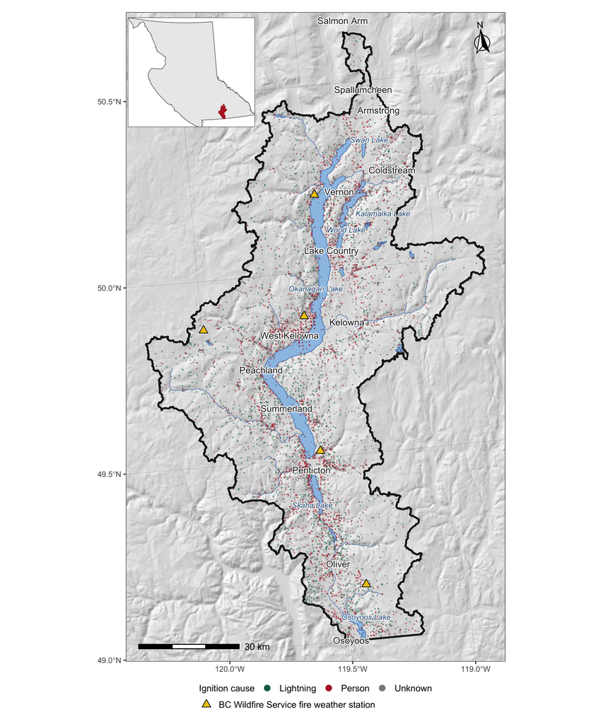

Figure 1: Study area, ignition record and weather record. Okanagan River watershed group, British Columbia Freshwater Atlas (GeoBC Branch, 2026b), 795,417 ha. Points are the 8,176 wildfire incidents recorded inside the basin between 1980 and 2025 in the BC Wildfire Service historical incident record (BC Wildfire Service, 2026a), coloured by reported cause; 3,633 carry no recorded cause and are drawn as unknown. Triangles are the 5 BC Wildfire Service fire weather stations inside the basin (BC Wildfire Service, 2026b), which are the entire weather record used here. Lakes, streams and municipalities are from the Freshwater Atlas and the provincial administrative boundaries (GeoBC Branch, 2026c, 2026d; Governance and Structure Branch, 2026). Relief is a hillshade of a 99 m digital elevation model (Amazon Web Services, 2026). Coordinate reference system NAD83 / BC Albers, EPSG:3005; graticule labelled in WGS84 degrees. Representative fraction approximately 1:861,000 at a 5.2 inch panel width.

## 2.2 Fire Danger Systems

Since 1970 fire danger in Canada has been rated with the Canadian Forest Fire Weather Index System (Canadian Forest Service Fire Danger Group, 2025), one part of the Canadian Forest Fire Danger Rating System. Stocks et al. (1989) described that rating system as four modules, “the now familiar Canadian Forest Fire Weather Index (FWI) System, the recently introduced Canadian Forest Fire Behavior Prediction (FBP) System, a proposed Canadian Forest Fire Occurrence Prediction (FOP) System, and the incomplete Accessory Fuel Moisture System” (Stocks et al., 1989, p. 451), the last intended to carry fuel-specific moisture codes for fuels such as cured grass and deciduous leaf litter. Stephen W. Taylor & Alexander (2006) later described two primary subsystems, the Fire Weather Index System and the Fire Behaviour Prediction System (Forestry Canada Fire Danger Group, 1992). The two divide the problem in a way that matters for this study. The Fire Weather Index System rates the weather against one standard fuel, since “FWI1987 was designed to track conditions in a generalized pine forest (similar to C-3)” (Canadian Forest Service Fire Danger Group, 2025, p. 3), whereas the Fire Behaviour Prediction System turns those ratings into spread rate and intensity for a mapped fuel type. Fire danger was measured here with the first of the two, in both of the versions now in circulation, and because the two versions are not interchangeable every value below carries its version.

FWI1987 is the System specified by Van Wagner (1987). Its six components are three fuel moisture codes, the Fine Fuel Moisture Code, the Duff Moisture Code and the Drought Code, and three fire behaviour indices built from them, the Initial Spread Index, the Buildup Index and the Fire Weather Index. A seventh quantity, the Daily Severity Rating, is a power transform of the Fire Weather Index and accumulates over a season into the seasonal severity rating. Its weather inputs are air temperature, relative humidity, ten-metre open wind speed and 24 hour rainfall (Lawson & Armitage, 2008), taken from one observation per day at 13:00 local daylight time. No reference period normalises it, because the codes are a bookkeeping system carried from day to day, so a value depends on the whole preceding sequence and not only on the day it describes.

FWI2025 (Canadian Forest Service Fire Danger Group, 2025) kept those components and changed how they were computed. The Fine Fuel Moisture Code was calculated hourly, on a modification of the diurnal method of Van Wagner (1977), with the drying time lag halved, and under the right conditions it continued to dry overnight. The report grounded that change in field moisture data, stating that “Observations of litter moisture from the field have suggested that the drying rate in the FFMC model itself is too slow” (Canadian Forest Service Fire Danger Group, 2025, p. 19) and citing the diffusivity experiments of Anderson (1990), which found response times of 0.2 to 37 hours in recently dead fine fuels and 0.5 to 10 hours in weathered ones. The field evidence that litter moisture departs from the standard code is older than the update. B. Mike Wotton & Beverly (2007) analysed litter moisture sampled at sites across Canada from 1939 to 1961 and found that forest type, stand density, season and duff moisture each changed the relation between the Fine Fuel Moisture Code and surface litter moisture, and fitted a model adjusting the standard code for them. Outside Canada, J. Zhang, Cui, Wei, Huang, & Di (2017) found that the standard hourly code underestimated dead fine fuel moisture in larch, Scots pine and oak stands of the Great Xing’an Mountains of China, while a locally calibrated version fitted with R<sup>2</sup> from 0.920 to 0.969, and Alves, Almeida, Reis, Raposo, & Viegas (2024) found from field measurements of maritime pine litter in central Portugal from 2014 to 2023 that correcting the code to field moisture raised the indices under dry conditions but did not improve the prediction of fire numbers or burned area. Canopy interception of the first 0.5 mm of rain became cumulative within a rain event and reset after six rain-free hours rather than at the end of each day, and the same six hour constant governed the 1.5 mm and 2.8 mm effective rainfall thresholds of the Duff Moisture Code and the Drought Code. Those two codes were also computed hourly, drying only between sunrise and sunset, with sunrise and sunset derived from latitude, longitude and date. The Initial Spread Index took the Fire Behaviour Prediction System wind function (Forestry Canada Fire Danger Group, 1992), which limits the effect of winds above 40 km h<sup>-1</sup>. The Buildup Index, the Fire Weather Index and the Daily Severity Rating were unchanged in form.

Three further components bear on how either version is run, and this study used or set aside each of them. The first is the overwintered Drought Code. C. C. Hanes et al. (2023) found in instrumented plots in Alberta and Ontario that the Drought Code “predicted the moisture content of the deeper organic layers (10–18 cm depths) well” (C. C. Hanes et al., 2023, p. 836), and described the overwintering procedure that adjusts its spring starting value from the previous fall value and the overwinter precipitation. The 2025 report recommended that calculations continue until three consecutive days with a maximum temperature below 5 °C, which removes the need to estimate the carry-over fraction, and that where “the agency weather station network does not calculate the FWI System up to this date” an alternate weather stream such as “a nearby Environment and Climate Change Canada (ECCC) station” be used (Canadian Forest Service Fire Danger Group, 2025, pp. 50–51). This study restarted the code each spring, for the reason given under the startup rules below. The second is the fire season start rule, taken up under the season window below. The third is the grassland components. FWI2025 added optional grassland codes built on grass moisture models for standing and matted cured grass, together with two new optional inputs, solar radiation and curing (Canadian Forest Service Fire Danger Group, 2025, pp. 13, 23), extending a line of work that includes the matted cured grass moisture model that Kidnie & Wotton (2015) developed and tested in southern Ontario tallgrass prairie. The grassland and peatland components were excluded here, because this is a forest baseline and the two versions were compared only where they overlap.

Fuel type enters the Fire Behaviour Prediction System and not the Fire Weather Index System. In British Columbia the provincial fuel type layer described by Perrakis, Eade, & Hicks (2018) was assembled from the Vegetation Resource Inventory into a dataset of “over 4.7 million VRI polygons” covering more than 94 million hectares (Perrakis et al., 2018, p. 3), each assigned to a fuel type by rule, and its authors cautioned that “the FBP fuel typing process is inherently subjective, and the vegetation communities of BC frequently fall through the cracks between the FBP fuel types” (Perrakis et al., 2018, p. 2). For this basin the author built a fuel type map from the 2020 Vegetation Resource Inventory with that rule set, together with the stand-adjusted fine fuel moisture model of B. Mike Wotton & Beverly (2007) and a Fire Behaviour Prediction System run for single days in the summer of 2021 on gridded daily weather, in unpublished prototype work (Murphy, 2022), and that work is the reason the present study held fuel fixed. A trend in the Fire Weather Index System is a trend in the weather rated against one standard fuel, and a trend in fire behaviour across the basin’s fuel types would need a fuel map for every season of the record, which this study did not build.

## 2.3 Weather Record

The weather record was the BC Wildfire Service weather data mart (BC Wildfire Service, 2026c), a public directory of hourly observations from the provincial fire weather station network. It was used in preference to a gridded reanalysis for two reasons. It carries genuinely hourly precipitation, without which pathway A cannot be run as specified rather than approximated, and Canadian Forest Service Fire Danger Group (2025) states the caveat that a reanalysis would have imposed on this basin directly, that “numerical weather model outputs are not strictly the same as point observations of weather from a weather station. At the grid cell scale, outputs from numerical models typically represent what can be thought of as average conditions across that cell.” A cell of roughly nine kilometres across terrain running from 273 m to 2,604 m is a coarse instrument.

The stations belong to the BC Wildfire Service weather station network. Its catalogue record states that “BCWS operates a network of automated hourly reporting weather stations to support all aspects of fire management”, that “The data are used as input to the Canadian Forest Fire Danger Rating System, as a basis for weather forecasting and for climate monitoring”, and that “Sensors at the weather stations monitor temperature, relative humidity, wind speed and direction and rainfall” (BC Wildfire Service, 2026b). The catalogue layer holds one point per actively reporting station, with a numeric station code, a name, a three-letter acronym, latitude, longitude, elevation and installation date. The 5 stations inside the basin were Penticton RS (station 328, 492 m, installed 1988), Brenda Mines (station 283, 1,463 m, installed 1989), McCuddy (station 334, 1,023 m, installed 1989), Fintry (station 298, 526 m, installed 1990), and West Kelowna (station 1277, 650 m, installed 2016), and each first appeared in the archive in the season it was installed. The hourly archive for those stations is the BC Wildfire Service weather data mart (BC Wildfire Service, 2026c), which carries for every station and hour the observed precipitation, temperature, relative humidity, wind speed and wind direction, the hourly Fine Fuel Moisture Code, Initial Spread Index and Fire Weather Index, and once a day the daily precipitation and the six FWI1987 codes that the service computed operationally.

The record retrieved was every hourly observation from the 5 stations the BC Data Catalogue places inside the basin polygon (BC Wildfire Service, 2026b), for every season the data mart holds (BC Wildfire Service, 2026c). Seasons 1987 to 2023 are published as one province-wide file per year and seasons 2024 onward as one file per day, and both layouts were read in full and filtered to the basin stations, which kept 1,199,767 hourly observations out of 55,437,531 province-wide rows for the 1987 to 2025 seasons.

Timestamps in that archive are Local Standard Time, which was verified rather than assumed. The FWI1987 codes that BC Wildfire Service computed operationally appeared in the record at hour 12 and at no other hour, and because the standard fire weather observation is 13:00 local daylight time, hour 12 is 13:00 LDT and the stamp is Pacific Standard Time, UTC-8, year round. The modal hour of daily maximum temperature in summer fell where that reading implies.

Table 2: The weather record. Coverage is the share of the 1 April to 30 September hours in which temperature, humidity and wind were all observed, before any gap filling. A season is kept when coverage reaches 95 per cent and no single gap exceeds 24 hours.

[output not shown]

Table 2 gives the result. 104 station-seasons across 5 stations survived, spanning 1991 to 2025, 31 distinct seasons. The daily codes appeared at hour 12 in 39,095 records and at other hours in 0, which is what fixed the convention. The modal hour of daily maximum temperature in summer was 15:00 Local Standard Time, three hours after solar noon at this longitude, which is consistent with it.

```r
# The caption's counts are the same objects the station table reports.
n_dropped <- sum(cover$status == "dropped, coverage")
cov_cap <- sprintf(paste(
  "Station reporting by season. Each cell is one station-season, shaded by the",
  "share of the 1 April to 30 September hours in which temperature, humidity",
  "and wind were all observed; an outlined cell met the 95 per cent rule and",
  "was kept, a crossed cell was dropped for coverage, and a blank cell is a",
  "season in which the station did not report. %d station-seasons at %d",
  "stations were kept and %d dropped, over %d to %d."),
  n_kept, n_stations_kept, n_dropped, yr_first, yr_last)
# The two facts the sentence under the figure states, computed from the same
# table: the share of dropped seasons before 2000, and the first season each
# station reported at all.
n_dropped_pre2000 <- sum(cover$status == "dropped, coverage" & cover$year < 2000)
first_report <- tapply(cover$year[cover$status != "station not reporting"],
                       cover$station_name[cover$status != "station not reporting"], min)
late_station <- names(first_report)[which.max(first_report)]
```

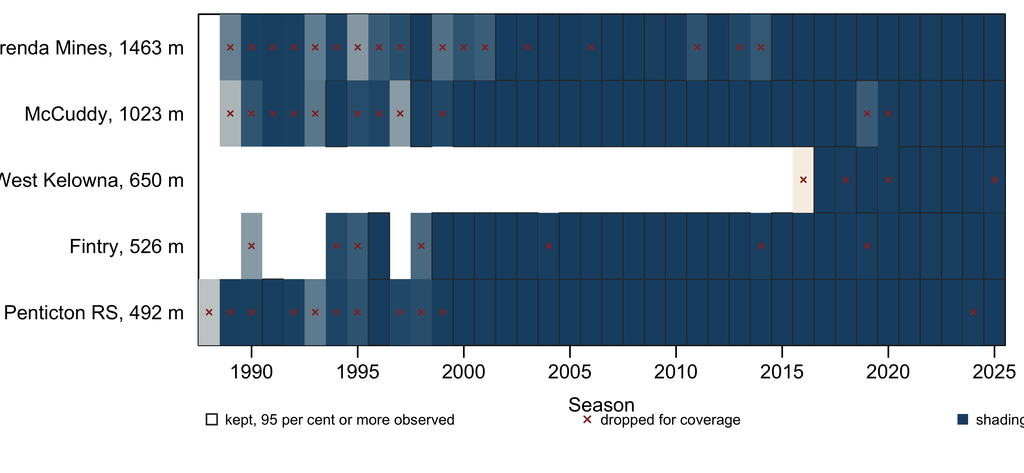

Figure 2: Station reporting by season. Each cell is one station-season, shaded by the share of the 1 April to 30 September hours in which temperature, humidity and wind were all observed; an outlined cell met the 95 per cent rule and was kept, a crossed cell was dropped for coverage, and a blank cell is a season in which the station did not report. 104 station-seasons at 5 stations were kept and 49 dropped, over 1991 to 2025.

```r
# One row per station in elevation order, one cell per season, shaded by the
# share of the 1 April to 30 September hours observed. A kept season is outlined,
# a season dropped for coverage is crossed, and a season in which the station did
# not report is left blank, so the switch-on and switch-off pattern of the
# network is visible in a way the station table cannot show.
cv <- cover
cv$station <- station_prose(cv$station_name)
st <- unique(cv[, c("station", "elevation_m")]); st <- st[order(st$elevation_m), ]
yrs <- sort(unique(cv$year))
ramp <- colorRampPalette(c("#F7EFE6", "#1B4F72"))(101)
op <- par(mar = c(3.2, 8.4, 0.6, 0.8), oma = c(2.2, 0, 0, 0), mgp = c(2, 0.6, 0), cex = 0.75)
plot(NA, xlim = range(yrs) + c(-0.5, 0.5), ylim = c(0.5, nrow(st) + 0.5),
     xlab = "Season", ylab = "", yaxt = "n", xaxs = "i", yaxs = "i")
axis(2, at = seq_len(nrow(st)),
     labels = sprintf("%s, %d m", st$station, round(st$elevation_m)),
     las = 1, tick = FALSE)
for (i in seq_len(nrow(st))) for (y in yrs) {
  r <- cv[cv$station == st$station[i] & cv$year == y, ]
  if (!nrow(r) || r$status == "station not reporting") next
  rect(y - 0.5, i - 0.5, y + 0.5, i + 0.5,
       col = ramp[1 + round(100 * r$observed_fraction)], border = NA)
  if (r$status == "kept")
    rect(y - 0.5, i - 0.5, y + 0.5, i + 0.5, border = "grey20", lwd = 0.7)
  else points(y, i, pch = 4, cex = 0.55, col = "#943126")
}
par(xpd = NA)
legend(min(yrs) - 0.5, -0.35, horiz = TRUE, bty = "n", cex = 0.75,
       legend = c("kept, 95 per cent or more observed", "dropped for coverage",
                  "shading, share of hours observed, 0 (pale) to 1 (dark)"),
       pch = c(0, 4, 15), col = c("grey20", "#943126", "#1B4F72"),
       pt.cex = c(1.2, 0.7, 1.2))
par(op)
```

Figure 2 shows what the table cannot, which is when each station reported. The network was switched on and off for operational reasons, so 33 of the 49 dropped seasons fell before 2000, and the West Kelowna station reported only from 2016.

### 2.3.1 Season Window

The window was a fixed calendar one, 1 May to 30 September, 153 days, with the calculation spun up from 1 April so that thirty days of weather preceded the first reported day.

That was a departure from the original design, which proposed the Canadian rule that section C-2.3 of Canadian Forest Service Fire Danger Group (2025) describes as the criterion most often used across Canada, to “start calculation three days after the disappearance of snow cover”, or, where snow cover cannot be observed, after three days above 12 degrees Celsius (Lawson & Armitage, 2008). The rule was implemented, run, and abandoned, because these stations do not report through the winter, so the rule fired on whatever day a station was switched on, and the station reporting record above shows that the switch-on date varied by station and season for operational reasons. The same constraint has been met before. R. D. Field et al. (2015), building the Global Fire Weather Database, noted that data for their Canadian comparison stations “were available only for the fire season, which was determined using a temperature threshold” (R. D. Field et al., 2015, p. 1411), and C. Hanes, Wotton, Woolford, Martell, & Flannigan (2020), working with fire weather stations in Alberta and Ontario, took winter precipitation from nearby Environment and Climate Change Canada stations because “fire weather stations are not operated during the winter” (C. Hanes et al., 2020, p. 5).

One consequence was stated rather than repaired. Fire season length could not be estimated from this network and was therefore not among the metrics, although lengthening season is among the most-reported fire danger trends, because a network whose stations are switched on and off for operational reasons cannot measure when a season begins. The published definitions of the season answer different questions and fail in different ways on a record like this one. The weather rule of Lawson & Armitage (2008) and B. M. Wotton & Flannigan (1993), which McElhinny et al. (2020) stated as a season “active on the fourth day following 3 consecutive days with a maximum temperature of 12 °C or higher” and over “after 3 consecutive days with a maximum temperature of 5 °C or lower” (McElhinny et al., 2020, p. 1826), dates the weather season and needs a record that runs through the shoulder months. Jolly et al. (2015) defined fire weather season length from the danger series itself, as “the number of days each year when fire danger is above half its value range” (Jolly et al., 2015, p. 2), and found that it lengthened across 25.3 per cent of the Earth’s vegetated surface from 1979 to 2013, a definition that dates the danger season and needs the stations to be reporting before the first such day. Definitions based on fires rather than weather date the fire season: Westerling (2016) measured it from the first discovery to the last control of a large fire and found western United States forest fire seasons in 2003 to 2012 more than 84 days longer than in 1973 to 1982, Albert-Green, Dean, Martell, & Woolford (2013) dated its start and end where a smoothed daily lightning-fire risk curve crossed set thresholds in Alberta and Ontario, and Granville, Woolford, & Dean (2026) dated it from observed wildfires across Ontario and found it lengthening by a median of about 0.5 days per year in the northwest. Those need a complete and well-dated ignition record, which Section 2 shows the basin’s record is not after 2000. The metrics that remained here were counts and sums over a window of fixed length, which the network can measure, and what that window gives up is taken up in Section 5.

### 2.3.2 Data Limitation: Gaps and Startup

Runs of missing temperature, humidity or wind up to 24 hours were filled by linear interpolation, since the reference implementation requires a gap-free hourly stream, and missing precipitation was filled with zero, because rain cannot be invented. A station-season was kept only where at least 95 per cent of the 1 April to 30 September hours were observed and no single gap exceeded 24 hours.

Filling a gap with no rain makes a missing wet spell look dry and pushes danger up. The direction matters and is stated. Coverage in this record was worse early than late, so this bias, where it acted, inflated danger in early seasons and therefore worked against an increasing trend rather than for one. It was identical across the three series by construction, since all three ran on the same filled record, and so could not move a contrast between versions.

Each station-season started from FFMC 85, DMC 6 and DC 15, the values Van Wagner (1987) gives and the reference implementation defaults to. The Drought Code was not overwintered, because these stations report no winter weather for an overwintering calculation to run on. That departs from provincial practice, since C. Hanes et al. (2020) reported that “the western provinces regularly overwinter the DC” (C. Hanes et al., 2020, p. 2), adjusting the fall value by the precipitation received over winter. The departure matters for absolute counts. McElhinny et al. (2020) computed a global Fire Weather Index reanalysis for 1979 to 2018 both ways and found that “even a modest difference in FWI values at start-up can lead to important differences in the number and spatial distribution of fire spread days between the overwintered and default calculations” (McElhinny et al., 2020, p. 1829), illustrated with the 2016 season over North America, when fuel moisture before the Fort McMurray fire in Alberta followed low overwinter precipitation and severe fall drought. The Drought Code here therefore carried startup information into early May in every season, identically in all three series, and its effect on absolute Drought Code, Buildup Index and extreme-day levels is reported with the implementation checks in Section 4.

## 2.4 Fire Activity

The ignition record was the BC Wildfire Service historical incident set (BC Wildfire Service, 2026a), clipped to the basin, 8,176 incidents over the 1980 to 2025 seasons.

Two properties of that record governed what could be asked of it, and neither was repaired here, because neither can be. First, many incidents could not be placed on a day at all. 6,304 of 8,176 incidents, 77.1 per cent, carried an ignition date, and the remaining 1,872 could not enter a daily series at any threshold. The missing dates were not spread evenly, and they did not concentrate where intuition puts them, in that the earliest decade in the record was 100 per cent dated and the most recent was 46 per cent. Missing date and missing cause were largely the same records. Second, cause attribution was not stationary. Table 3 gives both by decade, and a lightning-caused count that falls after 2000 may record a change in how cause was coded rather than a change in ignition.

```r
completeness$decade <- paste0(completeness$year %/% 10 * 10, "s")
cd <- do.call(rbind, lapply(split(completeness, completeness$decade), function(d) {
  data.frame(
    Decade = d$decade[1],
    Incidents = sum(d$n_incidents),
    Dated = sum(d$n_dated),
    `Dated %` = round(100 * sum(d$n_dated) / sum(d$n_incidents), 1),
    Attributed = sum(d$n_caused),
    `Attributed %` = round(100 * sum(d$n_caused) / sum(d$n_incidents), 1),
    check.names = FALSE)
}))
fmt_tbl(cd)
```

Table 3: Completeness of the ignition record by decade. A dated incident can be placed on a day; an attributed incident carries a recorded cause. Both fall sharply after 2000 and the same records are usually missing both.

| Decade | Incidents | Dated | Dated % | Attributed | Attributed % |
| --- | --- | --- | --- | --- | --- |
| 1980s | 1,338 | 1,338 | 100.0 | 1,274 | 95.2 |
| 1990s | 1,116 | 1,116 | 100.0 | 995 | 89.2 |
| 2000s | 3,058 | 2,100 | 68.7 | 991 | 32.4 |
| 2010s | 1,587 | 1,259 | 79.3 | 653 | 41.1 |
| 2020s | 1,077 | 491 | 45.6 | 630 | 58.5 |

```r
# Season-by-cause counts and the two completeness measures, with the pooled
# shares before 2000 and from 2000 onward computed here for the caption.
ibs <- read.csv(file.path(derived, "ignitions-by-season.csv"),
                stringsAsFactors = FALSE)
cause_tab <- xtabs(n ~ fire_cause + fire_year, ibs)
cause_tab <- cause_tab[c("Lightning", "Person", "Unknown"), , drop = FALSE]
share <- function(rows, col) 100 * sum(completeness[[col]][rows]) / sum(completeness$n_incidents[rows])
ign_cap <- sprintf(paste(
  "Ignitions by season and the completeness of their records. Upper panel,",
  "incidents per season by reported cause, %s in all. Lower panel, the share",
  "of incidents carrying an ignition date and the share carrying a recorded",
  "cause, which were %.0f and %.0f per cent before 2000 and %.0f and %.0f per",
  "cent from 2000 onward. Both panels are the same records, so the fall in the",
  "lower panel is what makes the cause split in the upper panel unreadable as",
  "an ignition trend after 2000."),
  n_fmt(n_total_incidents),
  share(completeness$year < 2000, "n_dated"), share(completeness$year < 2000, "n_caused"),
  share(completeness$year >= 2000, "n_dated"), share(completeness$year >= 2000, "n_caused"))
```

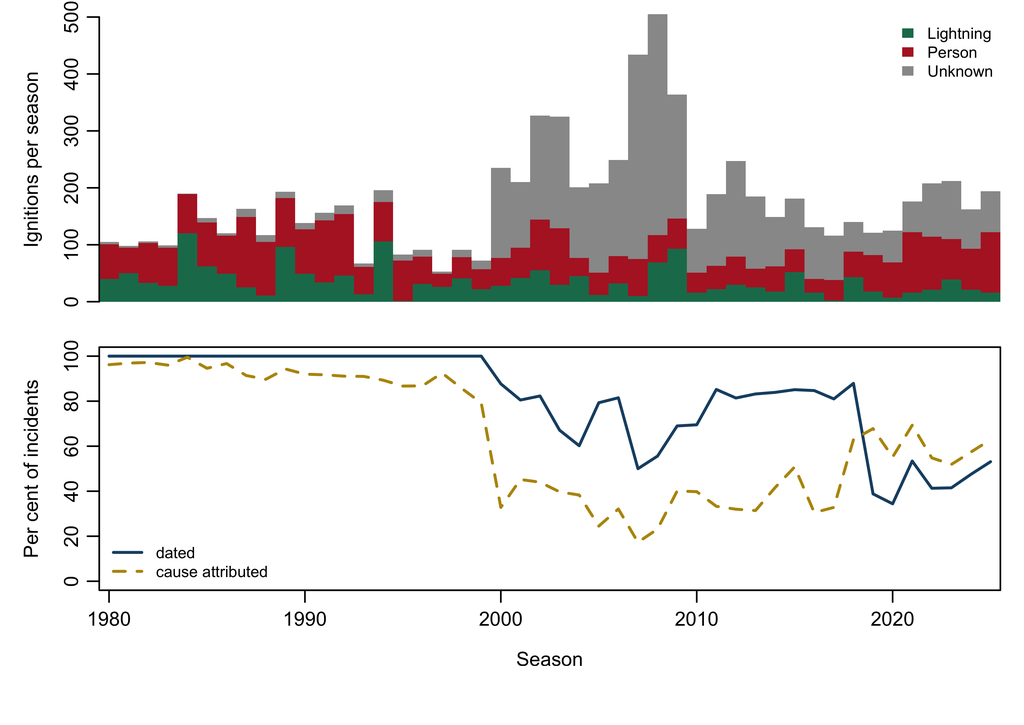

Figure 3: Ignitions by season and the completeness of their records. Upper panel, incidents per season by reported cause, 8,176 in all. Lower panel, the share of incidents carrying an ignition date and the share carrying a recorded cause, which were 100 and 92 per cent before 2000 and 67 and 40 per cent from 2000 onward. Both panels are the same records, so the fall in the lower panel is what makes the cause split in the upper panel unreadable as an ignition trend after 2000.

```r
# Two panels on one season axis. The bars are stacked by cause in the palette
# the study-area map uses; the lines are the two completeness measures from the
# same completeness table the decade table summarises.
cause_cols <- c(Lightning = "#1B7A5A", Person = "#B3242B", Unknown = "grey60")
yrs2 <- as.integer(colnames(cause_tab))
op <- par(mfrow = c(2, 1), mar = c(1.2, 4.2, 0.6, 1), oma = c(2.5, 0, 0, 0),
          mgp = c(2.4, 0.7, 0), cex = 0.75)
barplot(cause_tab, col = cause_cols[rownames(cause_tab)], border = NA,
        names.arg = rep("", ncol(cause_tab)), ylab = "Ignitions per season",
        space = 0, xaxs = "i")
legend("topright", legend = rownames(cause_tab), fill = cause_cols[rownames(cause_tab)],
       border = NA, bty = "n", cex = 0.8)
par(mar = c(3.2, 4.2, 0.6, 1))
plot(completeness$year, completeness$pct_dated, type = "l", lwd = 1.8,
     col = "#1B4F72", ylim = c(0, 100), xlab = "Season",
     ylab = "Per cent of incidents", xaxs = "i", xlim = range(yrs2) + c(-0.5, 0.5))
lines(completeness$year, completeness$pct_caused, lwd = 1.8, col = "#B7950B", lty = 2)
legend("bottomleft", legend = c("dated", "cause attributed"),
       col = c("#1B4F72", "#B7950B"), lwd = 1.8, lty = c(1, 2), bty = "n", cex = 0.8)
par(op)
```

Figure 3 shows the same records season by season. The upper panel gives the counts by cause and the lower panel the two completeness measures, and the fall in the lower panel after 2000 is what makes the cause split in the upper panel unreadable as an ignition trend.

The design responded to both rather than caveating them. The ignition models below carry season as a fixed effect, so the danger coefficient is identified only from day-to-day variation inside a season. Reporting completeness and cause coding both change between seasons and neither changes within one, so a between-season contrast would confound the danger effect with the record keeping and a within-season contrast cannot. Three response series were modelled, lightning, person-caused and all causes together, because the all-cause series cannot be affected by cause coding at all and is therefore the one that decides when the three disagree. Because detection of small fires also improved over the record, every result was reported at three minimum sizes, no limit, one hectare and four hectares, and a conclusion that survived at only one threshold was reported as not surviving.

# 3 Methods

## 3.1 Study Design

FWI1987 and FWI2025 differ in version and in input resolution simultaneously, so comparing one against the other answers no question about either. Three series were computed from a single hourly weather record, and each contrast moved one thing (Table 4).

Table 4: The three fire danger series and what separates them.

| Series | System | Weather input | Pathway |
| --- | --- | --- | --- |
| S1 | FWI1987 | daily 13:00 LDT observation | the legacy configuration |
| S2 | FWI2025 | daily 13:00 LDT observation | pathway C of Canadian Forest Service Fire Danger Group (2025) |
| S3 | FWI2025 | observed hourly weather | pathway A of Canadian Forest Service Fire Danger Group (2025) |

S1 against S2 isolated the version change at fixed input, S2 against S3 isolated the input resolution change at fixed version, and S1 against S3 was the operational contrast an agency faces on migration, the sum of the other two. All three ran on the same weather, the same season window, the same startup values and the same gap filling, so nothing that differed between them was an artefact of the record.

Pathway C is the report’s own procedure for the legacy observation. The 13:00 observation was converted to estimated daily maxima and minima using national constants, daily maximum temperature being about 2 degrees Celsius above the 13:00 value, minimum wind speed 10 per cent of it and maximum wind speed 30 per cent above it, and humidity carried through at constant vapour content; those maxima and minima were then expanded to an hourly stream by the sinusoidal method of Beck & Trevitt (1989) with the default offset and decay coefficients of Table A-1 of Canadian Forest Service Fire Danger Group (2025). Daily rainfall, whose timing is unknown in a once-daily observation, was placed at the first hour after sunrise, which is the rule the report gives and the rule FWI1987 implicitly used.

## 3.2 Index Computation

FWI2025 was computed with the reference implementation published by the Canadian Forest Service Fire Danger Group (Canadian Forest Service Fire Danger Group, 2026), run unmodified at the version cited. It reproduced the standard output distributed with it exactly, to the last decimal place the file carries, over the 2,623 hour Petawawa Research Forest test record.

FWI1987 was implemented for this study in Python, so that both systems ran inside one process on one record, and the implementation was checked in two ways, both reported in the results. The first check was against the CRAN package `cffdrs`, version 1.9.2 (X. Wang et al., 2017, 2025), an independently published implementation maintained by the Canadian Forest Service, run through R over the same test record. The second was against the FWI1987 codes that BC Wildfire Service itself computed operationally at these stations at the time, which the data mart preserves alongside the raw observations, so that a different party, different code and a different decade met the same weather.

Two constants differ between Van Wagner (1987) as printed and Van Wagner & Pickett (1985) as programmed, and this implementation followed the program. The moisture transform coefficient is 147.2772, not the rounded 147.2 of the report, since 59.5 x 250 / 101 = 147.27722772 is the value that closes the scale; and the Duff Moisture Code moisture functions take the listing’s form. Using the rounded constants instead moved the Fine Fuel Moisture Code by up to 3.9 units over the test record, which would have entered a version comparison as a difference between systems when it is a difference between roundings.

## 3.3 Seasonal Metrics

The second question turns on the thresholding, so both schemes were built and neither was preferred.

Absolute thresholds are fixed numbers on the index scale applied unchanged to all three series, which is the scheme an agency uses, because a danger class is a number in a manual. Stephen W. Taylor & Alexander (2006) traced how Canadian danger classes were set from correlations between Fire Weather Index System values and historical fire occurrence, and reported that British Columbia defined its classes from the Fire Weather Index and the Buildup Index separately for three danger regions with different fire climates. Three thresholds were used. FFMC 91 was taken from section 4.1 of Canadian Forest Service Fire Danger Group (2025), so that counting days above it tested that report’s comparability sentence directly, and it is also the value above which the Canadian Wildland Fire Information System classes the Fine Fuel Moisture Code as extreme (R. D. Field et al., 2015). A Fire Weather Index above 30 is that system’s extreme class (R. D. Field et al., 2015), and a Fire Weather Index above 19 is the fire spread day threshold of Podur & Wotton (2011), which McElhinny et al. (2020) used to count spread days in their global reanalysis. R. D. Field et al. (2015) noted that such extreme thresholds “will be different in other regions” (R. D. Field et al., 2015, p. 1409), so the absolute counts here are Canadian classes applied to one basin and not local calibrations.

Relative thresholds are percentiles of each series’ own distribution over a common reference period, taken as 1991 to 2020, the current World Meteorological Organization normal, and fixed before any metric was computed. Climate extremes monitoring moved to thresholds of this kind because, in the review of X. Zhang et al. (2011), “few physically based thresholds have relevance in all parts of the world” (X. Zhang et al., 2011), and Jain et al. (2017) used the 99th percentile of the Fire Weather Index alongside counts of spread days for North America. British Columbia uses a threshold of the same kind operationally, since the head fire intensity layer of the provincial strategic threat analysis “was developed using the 90th percentile fire weather index value for an interpolated and elevation-adjusted analysis of weather station values” (BC Wildfire Service, 2026d). A day above a series’ own 90th percentile means the same thing in each series by construction, so a difference in trend under relative thresholds cannot be an artefact of the two systems sitting at different levels.

Percentile counts carry two known problems. X. Zhang et al. (2005) showed by Monte Carlo simulation that sampling error in a threshold estimated from a fixed base period leads to “overestimated exceedance rates outside the base period” (X. Zhang et al., 2005, p. 1641) and underestimated rates inside it, producing an artificial jump at the boundary, larger for higher percentiles and for positively autocorrelated observations, that a linear trend fitted across it reads as a trend, and they removed it with a bootstrap estimate of the in-base rates. That correction was applied here. For each season inside the 1991 to 2020 base period, the threshold was re-estimated with that season removed and each other base season in turn duplicated in its place, and the count for the season was the mean over those replacements, while the last 5 seasons, which lie outside the base period, used the threshold from the whole base period. X. Zhang et al. (2005) estimated a threshold for each calendar day, whereas the threshold here was estimated from all days of the season pooled, so the procedure was adapted from a daily to a seasonal threshold. Dunn & Morice (2022) then showed that trends computed from the same data over the same years differ when the reference period changes and the climate has shifted between the two periods, by about 1 day per decade, around 25 per cent, in the global HadEX3 warm-day index over 1961 to 2018 and by about 3 days per decade, around 50 per cent, at De Bilt (Dunn & Morice, 2022, p. 8). That problem has no correction, because it is a property of the choice rather than an error in the estimate, so the reference period was fixed before any metric was computed and a relative-threshold trend here is a statement about the 1991 to 2020 period as well as about its index.

One property of that construction is stated because it resembles a result and is not one. Inside the reference period the mean number of days above a series’ own 90th percentile is close to ten per cent of the days in it, in every series, by construction. The level of a relative count therefore carries no information about the version at all, and only its trend does.

Reference distributions were computed per station as well as per series, because pooling them would mix a valley station at 492 m with a ridge station at 1,463 m, and the percentile would then describe the network rather than the site.

## 3.4 Statistical Analysis

Trends were estimated with the non-parametric pairing that fire weather trend studies have adopted, the Theil-Sen slope with a Mann-Kendall test. Jain et al. (2017) applied that pairing to the potential fire season length and to the 99th percentile of the Fire Weather Index across North America from 1979 to 2015, computing the System from the North American Regional Reanalysis with field significance testing and a Canadian series truncated because the reanalysis ceased to assimilate Canadian precipitation observations after 2002, and Venäläinen et al. (2014) applied it to the Fire Weather Index over Europe from 1960 to 2012 with a Mann-Kendall test corrected for autocorrelation through an effective sample size, computing trends separately for the ERA-40 and ERA-Interim reanalyses. The Theil-Sen slope, the median of all pairwise slopes (Sen, 1968), was computed here over the 31 seasons from 1991 to 2025 that survived the coverage rule, on the actual season numbers so that a gap in the sequence was honoured rather than treated as a step of one. The median of pairwise slopes was preferred to least squares because Hirsch, Slack, & Smith (1982) showed that it was an unbiased estimator of a linear trend with considerably higher precision than a regression slope on highly skewed data, and seasonal counts of extreme days are skewed.

Significance was the Mann-Kendall test (Mann, 1945) with the variance correction of Hamed & Rao (1998), which inflates the variance of the test statistic by the serial correlation present in the series rather than assuming independence. Serial correlation alters the variance of the Mann-Kendall statistic (Yue, Pilon, Phinney, & Cavadias, 2002) and gives too large a rejection rate on trendless series (Bayazit & Önöz, 2007), and the literature offers four responses, prewhitening, trend-free prewhitening, variance correction and block bootstrap resampling (Önöz & Bayazit, 2012). Prewhitening was not used. Bayazit & Önöz (2007) found by simulation that it corrected the false rejection rate on trendless autocorrelated series but reduced the power of the test when a trend was present, and Yue et al. (2002) showed that removing a positive serial correlation component by prewhitening also reduced the magnitude of the trend itself (see also Yue & Wang, 2002). The uncorrected result was reported alongside the corrected one only to show the size of the correction.

One approximation in that correction is stated here. Coverage dropped seasons out of the middle of some station records, so the season sequence was not evenly spaced. The Mann-Kendall statistic itself is unaffected, because it depends on the order of the values and not on their spacing, and the Theil-Sen slope was computed on the actual season numbers so a gap is a gap. The Hamed and Rao variance correction, however, estimates autocorrelation at lags counted in observations rather than in years, which across a gap compares seasons further apart than the lag says. The direction of that error is knowable, because it attributes to lag one a correlation measured over two or more years, which is smaller, so the correction applied was smaller than the true one and the test less conservative than it would be on a complete record. A marginal result is therefore weaker than its q value suggests.

Metric families were corrected within each series by the false discovery rate procedure of Benjamini & Hochberg (1995). The eight metrics in a family were computed from one series and rise and fall with the same fire weather, so their tests were not independent. Benjamini & Yekutieli (2001) proved that the same procedure still controls the false discovery rate when the test statistics have positive regression dependency on those of the true null hypotheses, which metrics driven by one weather record were expected to satisfy, and Wilks (2016) showed by simulation that under moderate to strong correlation among tests the procedure becomes conservative rather than permissive. Wilks (2016) also found that only 3 of the 281 papers published in the Journal of Climate in the first half of 2014, 1.1 per cent, considered multiple testing at all. Confidence intervals on a single slope were percentile intervals over 2,000 moving-block bootstrap resamples of seasons, with the block construction described next.

Comparing the trends of two records that share most of their variability has a precedent in the evaluation of atmospheric temperature data sets. Santer et al. (2000) tested the trend in the series of differences between two data sets rather than the overlap of their separate confidence intervals, because the difference removes variability common to both, and found that roughly 30 per cent of data set pairs differed significantly in lower tropospheric trend, mainly through differences in measurement system, where overlapping intervals had not shown it. Wilks (1997) showed that applying the same resampling pattern to every element of a data vector carries the cross correlation between elements into the resampled statistics without the need to model it. The three series here came from one weather record and were strongly dependent, and each was also serially correlated from season to season. Resampling single seasons would keep the pairing between series but discard that serial correlation, which block bootstraps retain by resampling runs of consecutive observations (Kunsch, 1989; Politis & Romano, 1994), and Önöz & Bayazit (2012) found that a block bootstrap Mann-Kendall test had power comparable with the other corrections for serial dependence. The difference between two series’ slopes was therefore estimated by a moving-block bootstrap, drawing blocks of consecutive seasons with replacement and recomputing both slopes on the same resampled seasons in every one of 4,000 replicates, which kept the pairing between series by construction. Blocks were 3 seasons long for station records of 20 to 27 seasons, the cube root of the record length rounded up, which grows with the record but more slowly than it, as Kunsch (1989) required for consistency, and they were drawn from the seasons in order of occurrence so that a gap in a station record fell inside a block. The interval on the difference was the plain percentile interval, on which the bias-corrected and accelerated interval of Efron (1987) improves to second-order correctness (DiCiccio & Efron, 1996). The two-sided p value was computed under the null hypothesis, following the first guideline of Hall & Wilson (1991), that resampling should reflect the null hypothesis, whose violation they found can seriously reduce power. The resampled differences were centred on the observed difference, and p was the share of them lying at least as far from it as the observed difference lies from zero. It was corrected for false discovery rate within the eight metrics of one contrast at one station.

Daily fire occurrence has been modelled statistically since Bruce (1960), whose negative binomial model related daily counts to a fire danger rating index and which S. W. Taylor, Woolford, Dean, & Martell (2013) identified as the first stochastic model of fire occurrence. Canadian operational practice later moved to logistic models of fire presence, because, as S. W. Taylor et al. (2013) noted, “overdispersion is of concern when Poisson-based methods are used to model counts” (S. W. Taylor et al., 2013, p. 591). Martell, Otukol, & Stocks (1987) predicted the probability of a people-caused fire day in northern Ontario by logistic regression with a Poisson assumption for the daily count, and Martell, Bevilacqua, & Stocks (1989) added periodic functions of the calendar day to represent seasonal variation. Count models remain in use where the daily number is the quantity of interest. Plucinski, McCaw, Gould, & Wotton (2014) modelled daily human-caused bushfires in south-west Western Australia by negative binomial regression on fuel moisture, fitted on three years and tested on an independent fourth, and Xiao, Zhang, & Ji (2015) found that a negative binomial mixed model described forest fire counts in Guizhou, China, better than Poisson, zero-inflated and hurdle alternatives. The closest regional precedent is Magnussen & Taylor (2012), who modelled daily lightning- and human-caused fire occurrence across British Columbia from 1981 to 2000 by logistic regression on lightning strikes, forest cover, surface weather, atmospheric stability and Fire Weather Index System moisture codes, and under leave-one-year-out cross-validation predicted the daily provincial number of lightning fires at R = 0.83 and of human-caused fires at R = 0.55 (Magnussen & Taylor, 2012).

Daily ignition counts here were modelled by negative binomial regression with a log link (Lawless, 1987), because the response was a daily basin count rather than a cell-day presence. The linear predictor carried the daily basin danger value, two annual harmonics in day of year in the manner of Martell et al. (1989), season as a factor, and the number of stations that contributed to the basin mean that day, since no station reports in every season and the composition of the network changes. That last term cannot affect the comparison between series in any case, because all three are averaged over exactly the same stations on exactly the same days. The seasonal terms matter beyond this study, since Castel-Clavera et al. (2025) found in Mediterranean France that “relying solely on fire-weather indices is insufficient for efficient rating of fire activities” and that spatial and seasonal effects were needed, even though the Canadian Fire Weather Index was the most skilful index they tested. The lightning model carried no strike term, because no strike record covered the window, and lightning occurrence models depend on one. Flannigan & Wotton (1991) explained nearly 50 per cent of the variance in daily lightning fire counts in northwestern Ontario with the Duff Moisture Code and the multiplicity of negative discharges, B. M. Wotton & Martell (2005) found that a sheltered duff moisture index was the strongest predictor of ignition given a strike, and Wierzchowski et al. (2002) recorded one fire for every 50 lightning discharges in British Columbia against one for every 1,400 in Alberta. The Canadian Lightning Detection Network climatology of Kochtubajda & Burrows (2020) covers 1999 to 2018, so it misses the first 8 seasons of this window and the last 7.

Predictive skill was compared by leaving one season out at a time, refitting without it, and scoring the held-out season, which is the blocked cross-validation Roberts et al. (2017) recommend for temporally structured data, since random splits of such data result “in serious underestimation of predictive error” (Roberts et al., 2017), and the leave-one-year-out design Magnussen & Taylor (2012) used for British Columbia. Each held-out season was scored by its log likelihood under the refitted model, the logarithmic score that Gneiting & Raftery (2007) showed to be strictly proper. They also noted that scores for competing forecasts “are directly comparable if they refer to exactly the same set of forecast situations” (Gneiting & Raftery, 2007, p. 362), which held here because the three series were scored on the same days. Series were compared on held-out likelihood rather than on in-sample fit because three series computed from one weather record will all fit, and the question is which predicts. One caution from the index comparison literature applies directly. Eastaugh, Arpaci, & Vacik (2012) compared four hypothetical indices, three of them simple transformations of one another, and found that all the established comparators they examined except the c-index “indicate different predictive power between the effectively identical indices”, the differences “resulting from the frequency distributions of the index values rather than from any real difference in predictive power” (Eastaugh et al., 2012, p. 932). The three series here are close to transformations of one another, and a log-linear danger term is sensitive to the shape of their distributions, so a small likelihood difference between them is not evidence of a difference in predictive power.

What a window of 31 seasons cannot resolve was computed rather than hedged, following Weatherhead et al. (1998), who showed that the number of years needed to detect a trend grows with the variance and the lag-one autocorrelation of the noise, from about 10 to more than 20 years for a trend of 5 per cent per decade, and that a level shift from a change of instrument or site can raise that number by 50 per cent or more. Tiao et al. (1990) had shown that the precision of a trend estimate depends critically on autocorrelation and on record length, and F. Wang et al. (2020) showed by simulation that the power of the Mann-Kendall test rises with slope and record length, falls with variance, and that positive autocorrelation increases both the Type I and the Type II error. For each metric the minimum detectable trend was the slope at which a two-sided test at alpha 0.05 would reach 80 per cent power given the residual spread of that metric about its own Theil-Sen line, adjusted for the lower efficiency of the Theil-Sen estimator under normal errors and inflated for serial correlation by the factor that Weatherhead et al. (1998) derived for first-order autoregressive noise, the square root of (1 + phi) / (1 - phi), where phi is the lag-one autocorrelation of the residuals in season order. Phi was bounded between 0 and 0.9, so that a negative sample estimate could not make the detectable trend smaller than it would be for independent seasons. The extreme-day counts are counts of rare days, and Frei & Schär (2001) found that in a 100-year record a 1.5-fold change in the frequency of an event was detected with probability 0.6 when the event had an average return period of 30 days but only 0.2 at a return period of 100 days, so the least frequent thresholds were expected to be the least detectable. A null result was reported against the minimum detectable trend, so that “no trend detected” was kept separate from “no trend”.

# 4 Results

```r
series_daily <- read.csv(file.path(derived, "fwi-series-daily.csv"),
                         stringsAsFactors = FALSE)
series_daily$date <- as.Date(series_daily$date)
metrics <- read.csv(file.path(derived, "seasonal-metrics.csv"),
                    stringsAsFactors = FALSE)
thresh_pct <- read.csv(file.path(derived, "threshold-percentiles.csv"),
                       stringsAsFactors = FALSE)
basin <- read.csv(file.path(derived, "basin-daily.csv"), stringsAsFactors = FALSE)
basin$date <- as.Date(basin$date)

# Relative-threshold counts are replaced by the in-base bootstrap estimates of
# Zhang et al. (2005), computed from the same daily series and the same
# 1991 to 2020 base period. Out-of-base seasons are unchanged by construction;
# the check below stops the render if any is not.
corrected <- do.call(rbind, lapply(names(SERIES), function(s)
  inbase_corrected_counts(series_daily, s, probs = c(90, 95),
                          reference = c(1991, 2020))))
for (pp in c(90, 95)) {
  col <- paste0("n_fwi_p", pp)
  cc <- corrected[corrected$prob == pp, c("station_name", "series", "year", "count")]
  key_m <- paste(metrics$station_name, metrics$series, metrics$year)
  key_c <- paste(cc$station_name, cc$series, cc$year)
  new <- cc$count[match(key_m, key_c)]
  out_base <- metrics$year > 2020 & is.finite(metrics[[col]])
  if (any(abs(new[out_base] - metrics[[col]][out_base]) > 1e-9))
    stop("in-base correction changed an out-of-base count for ", col)
  metrics[[paste0(col, "_uncorrected")]] <- metrics[[col]]
  metrics[[col]] <- new
}
```

## 4.1 Implementation Checks

```r
val <- read.csv(file.path(derived, "fwi1987-validation.csv"),
                stringsAsFactors = FALSE)
opc <- read.csv(file.path(derived, "fwi1987-operational-check.csv"),
                stringsAsFactors = FALSE)

# The two blocks differ by ten orders of magnitude, so the differences are
# formatted as strings rather than left to the table's numeric printing, which
# would render machine epsilon as a wall of zeros.
fmt_diff <- function(x) ifelse(is.na(x), "", formatC(x, format = "g", digits = 3))

blk1 <- data.frame(
  Check = "against cffdrs",
  Component = val$component,
  n = format(val$n, big.mark = ","),
  `Max absolute difference` = fmt_diff(val$max_abs_diff),
  `Mean absolute difference` = fmt_diff(val$mean_abs_diff),
  `Correlation` = "",
  check.names = FALSE)

# The data mart names the operational columns in full; the initials are the
# component names used everywhere else in this document.
initials <- function(x) vapply(strsplit(x, "_"),
                               function(p) paste0(substr(p, 1, 1), collapse = ""),
                               character(1))
op_agg <- do.call(rbind, lapply(split(opc, opc$component), function(d) {
  data.frame(
    Check = "against operational codes",
    Component = initials(d$component[1]),
    n = format(sum(d$n), big.mark = ","),
    `Max absolute difference` = "",
    `Mean absolute difference` = fmt_diff(weighted.mean(abs(d$mean_bias), d$n)),
    `Correlation` = formatC(weighted.mean(d$pearson_r, d$n), format = "f", digits = 4),
    check.names = FALSE)
}))
rownames(op_agg) <- NULL
fmt_tbl(rbind(blk1, op_agg))
```

Table 5: Verification of the FWI1987 implementation. The first block compares it against the CRAN package cffdrs over the Petawawa Research Forest test record. The second compares it against the FWI1987 codes BC Wildfire Service computed operationally at these stations, pooled over all kept station-seasons.

| Check | Component | n | Max absolute difference | Mean absolute difference | Correlation |
| --- | --- | --- | --- | --- | --- |
| against cffdrs | FFMC | 109 | 9.95e-14 | 3.03e-14 |  |
| against cffdrs | DMC | 109 | 7.46e-14 | 2.24e-14 |  |
| against cffdrs | DC | 109 | 5.4e-13 | 1.78e-13 |  |
| against cffdrs | ISI | 109 | 5.86e-14 | 1.13e-14 |  |
| against cffdrs | BUI | 109 | 7.82e-14 | 2.47e-14 |  |
| against cffdrs | FWI | 109 | 1.1e-13 | 1.86e-14 |  |
| against cffdrs | DSR | 109 | 3.82e-14 | 6.33e-15 |  |
| against operational codes | BI | 18,149 |  | 10.7 | 0.9834 |
| against operational codes | DC | 18,178 |  | 165 | 0.9520 |
| against operational codes | DMC | 18,178 |  | 1.74 | 0.9912 |
| against operational codes | FFMC | 18,178 |  | 0.114 | 0.9960 |
| against operational codes | FWI | 18,149 |  | 1.23 | 0.9928 |
| against operational codes | ISI | 18,149 |  | 0.0696 | 0.9984 |

```r
max_cffdrs <- max(val$max_abs_diff)
op_r <- weighted.mean(opc$pearson_r, opc$n)
op_n <- sum(opc$n)
bias_of <- function(comp) {
  d <- opc[opc$component == comp, ]
  weighted.mean(abs(d$mean_bias), d$n)
}
r_of <- function(comp) {
  d <- opc[opc$component == comp, ]
  weighted.mean(d$pearson_r, d$n)
}
dc_bias <- bias_of("DROUGHT_CODE")
bui_bias <- bias_of("BUILDUP_INDEX")
ffmc_r <- r_of("FINE_FUEL_MOISTURE_CODE")
```

Table 5 gives both checks. Against `cffdrs` the two implementations agreed to 5.4e-13 across all seven components, which is machine precision, because they are the same arithmetic, and the check confirmed that the equations were transcribed correctly rather than that they are correct.

Against the operational codes, computed by a different party in a different decade, the weighted mean correlation over 108,981 station-days was 0.986. That check was not expected to be exact, and one of its disagreements was large and had a known cause. The mean absolute bias in the Drought Code was 165 units, and in the Buildup Index, which is computed from it, 10.7. BC Wildfire Service overwinters the Drought Code, carrying it from the previous autumn, whereas this study restarted it at 15 on 1 April, because these stations report no winter weather for an overwintering calculation to use. That is a difference in convention, not an error, and its direction is known, in that a restarted Drought Code is lower than an overwintered one. Every absolute Drought Code and Buildup Index level reported here is conditional on that convention, and it cannot affect any comparison between the three series, because all three restart identically.

The components that do not depend on the overwintered code agreed closely. The Fine Fuel Moisture Code correlated 0.996 with the operational value, which is the component the version comparison principally rests on.

## 4.2 Threshold Positions

```r
tp <- do.call(rbind, lapply(
  split(thresh_pct, list(thresh_pct$series, thresh_pct$component,
                         thresh_pct$threshold), drop = TRUE),
  function(d) data.frame(
    Series = unname(SERIES[d$series[1]]),
    Component = toupper(d$component[1]),
    Threshold = d$threshold[1],
    `Percentile of threshold` = round(mean(d$percentile_of_threshold, na.rm = TRUE), 1),
    `Days per season above` = NA_real_,
    `Reference median` = round(mean(d$reference_median, na.rm = TRUE), 1),
    check.names = FALSE)))
# Days per season above each absolute threshold, averaged over station-seasons.
days_above <- function(series, component, thr) {
  col <- switch(paste(component, thr),
                "ffmc 91" = "n_ffmc_ge91",
                "fwi 19" = "n_fwi_ge19",
                "fwi 30" = "n_fwi_ge30")
  mean(metrics[[col]][metrics$series == series], na.rm = TRUE)
}
key <- do.call(rbind, strsplit(rownames(tp), "\\."))
tp$`Days per season above` <- round(mapply(days_above, key[, 1], key[, 2],
                                           as.numeric(key[, 3])), 1)
tp <- tp[order(tp$Component, tp$Threshold, tp$Series), ]
rownames(tp) <- NULL
fmt_tbl(tp)
```

Table 6: Where each absolute threshold falls in each series’ own 1991 to 2020 reference distribution, averaged over stations. A threshold at the same percentile in every series would mean the three systems are interchangeable for counting extremes. The reference median is the median of that component over the same distribution.

| Series | Component | Threshold | Percentile of threshold | Days per season above | Reference median |
| --- | --- | --- | --- | --- | --- |
| S1: FWI1987, 13:00 observation | FFMC | 91 | 65.1 | 57.2 | 89.3 |
| S2: FWI2025, 13:00 observation | FFMC | 91 | 66.2 | 55.4 | 89.5 |
| S3: FWI2025, hourly observation | FFMC | 91 | 62.5 | 61.9 | 89.8 |
| S1: FWI1987, 13:00 observation | FWI | 19 | 52.5 | 78.1 | 19.3 |
| S2: FWI2025, 13:00 observation | FWI | 19 | 47.6 | 85.4 | 21.4 |
| S3: FWI2025, hourly observation | FWI | 19 | 52.6 | 77.8 | 19.5 |
| S1: FWI1987, 13:00 observation | FWI | 30 | 74.8 | 43.0 | 19.3 |
| S2: FWI2025, 13:00 observation | FWI | 30 | 72.4 | 46.7 | 21.4 |
| S3: FWI2025, hourly observation | FWI | 30 | 75.2 | 42.9 | 19.5 |

```r
ffmc91 <- subset(tp, Component == "FFMC" & Threshold == 91)
fwi19 <- subset(tp, Component == "FWI" & Threshold == 19)
p_s1 <- ffmc91$`Percentile of threshold`[grepl("S1", ffmc91$Series)]
p_s2 <- ffmc91$`Percentile of threshold`[grepl("S2", ffmc91$Series)]
p_s3 <- ffmc91$`Percentile of threshold`[grepl("S3", ffmc91$Series)]
d_s1 <- ffmc91$`Days per season above`[grepl("S1", ffmc91$Series)]
d_s2 <- ffmc91$`Days per season above`[grepl("S2", ffmc91$Series)]
d_s3 <- ffmc91$`Days per season above`[grepl("S3", ffmc91$Series)]
```

Table 6 tests the comparability sentence of Canadian Forest Service Fire Danger Group (2025) directly. A Fine Fuel Moisture Code of 91 sat at the 65.1th percentile of the S1 distribution, the 66.2th of S2 and the 62.5th of S3, which in days per season above it was 57.2 under S1, 55.4 under S2 and 61.9 under S3.

```r
# The comparability claim is about where a value sits, so the reading is stated
# in the two units that matter and neither is rounded away: the percentile spread
# across series, and the difference in days per season an agency would count.
pct_spread <- max(abs(p_s3 - p_s1), abs(p_s2 - p_s1))
day_gap <- d_s3 - d_s1
day_gap_pct <- 100 * day_gap / d_s1
```

The claim survived as a statement about levels and did not survive as a statement about counts. The three medians of the Fine Fuel Moisture Code over the reference period sat within about a unit of each other, so a value of 91 does mean much what it used to mean, but the same threshold selected 4.7 more days per season under S3 than under S1, a difference of 8 per cent, because the percentile it occupied moved by 2.6 points. Those are the same distributions, described two ways, and Figure 4 shows why, in that the curves sit almost on top of one another through the middle and separate where the threshold is.

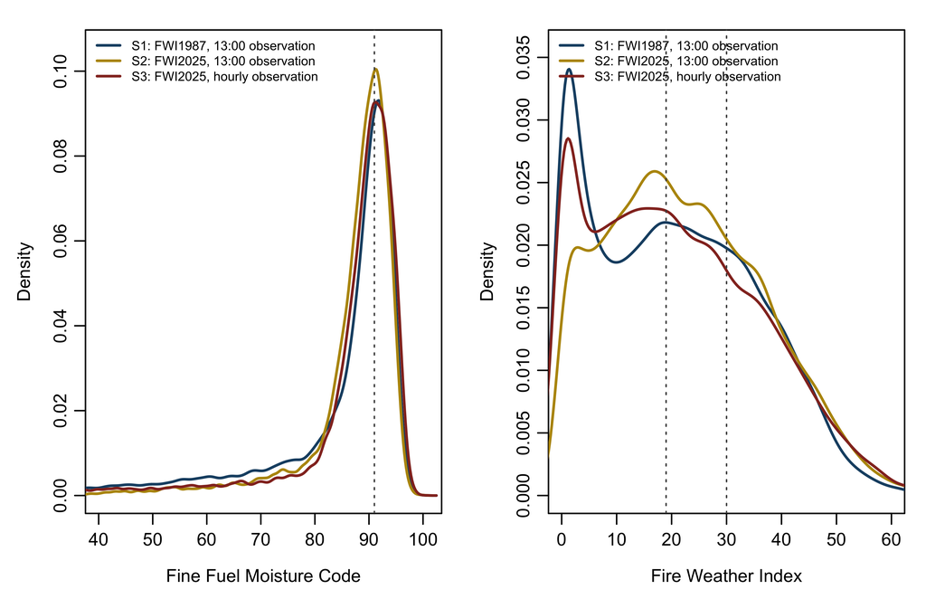

Figure 4: Distribution of the daily Fine Fuel Moisture Code and the daily Fire Weather Index over all kept station-days under the three series, with the absolute thresholds marked. The comparability claim of the 2025 report concerns the position of a value on the scale; an extreme-day count concerns the mass beyond a threshold, which is a different quantity.

```r
op <- par(mfrow = c(1, 2), mar = c(4, 4, 1.4, 1), mgp = c(2.4, 0.7, 0), cex = 0.75)
cols <- c(s1 = "#1B4F72", s2 = "#B7950B", s3 = "#943126")

plot_dens <- function(cols_prefix, xlab, cuts, xlim) {
  dens <- lapply(names(cols), function(s) {
    v <- series_daily[[paste0(s, "_", cols_prefix)]]
    density(v[is.finite(v)], na.rm = TRUE)
  })
  ymax <- max(vapply(dens, function(d) max(d$y), numeric(1)))
  plot(NA, xlim = xlim, ylim = c(0, ymax * 1.05), xlab = xlab,
       ylab = "Density", main = "")
  for (i in seq_along(dens)) lines(dens[[i]], col = cols[i], lwd = 1.8)
  abline(v = cuts, lty = 3, col = "grey30")
  legend("topleft", legend = unname(SERIES), col = cols, lwd = 1.8, bty = "n",
         cex = 0.72)
}
plot_dens("ffmc", "Fine Fuel Moisture Code", 91, c(40, 101))
plot_dens("fwi", "Fire Weather Index", c(19, 30), c(0, 60))
par(op)
```

## 4.3 Mechanism

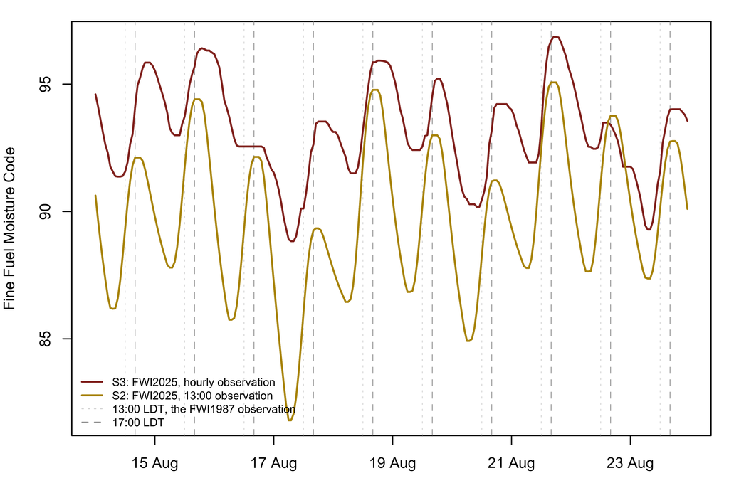

Figure 5: Ten days of the hourly Fine Fuel Moisture Code at Penticton RS in August 2003, under FWI2025 driven by the observed hourly weather and under FWI2025 driven by the 13:00 observation alone. Both are the same system on the same days, and the only difference is the weather input the System received. The vertical lines mark 13:00 local daylight time, the hour FWI1987 observes, and 17:00, the hour a daily value conventionally represents.

```r
ex <- read.csv(file.path(derived, "example-season-hourly.csv"),
               stringsAsFactors = FALSE)
ex$t <- as.POSIXct(sprintf("%04d-%02d-%02d %02d:00:00", ex$yr, ex$mon, ex$day, ex$hr),
                   tz = "UTC")
win <- ex[ex$mon == 8 & ex$day >= 14 & ex$day <= 23, ]

op <- par(mar = c(3.2, 4, 1.2, 1), cex = 0.8)
plot(win$t, win$s3_ffmc, type = "l", col = cols["s3"], lwd = 1.6,
     ylim = range(c(win$s3_ffmc, win$s2_ffmc), na.rm = TRUE),
     xlab = "", ylab = "Fine Fuel Moisture Code", xaxt = "n")
lines(win$t, win$s2_ffmc, col = cols["s2"], lwd = 1.6)
axis.POSIXct(1, win$t, format = "%d %b")
# The hour markers are drawn thin and pale on purpose: they locate the two
# sampling hours without competing with the curves, which are the subject.
abline(v = win$t[win$hr == 12], col = "grey86", lty = 3, lwd = 0.6)
abline(v = win$t[win$hr == 16], col = "grey62", lty = 2, lwd = 0.6)
lines(win$t, win$s3_ffmc, col = cols["s3"], lwd = 1.6)
lines(win$t, win$s2_ffmc, col = cols["s2"], lwd = 1.6)
legend("bottomleft", bty = "n", cex = 0.75,
       legend = c(unname(SERIES[c("s3", "s2")]),
                  "13:00 LDT, the FWI1987 observation", "17:00 LDT"),
       col = c(cols["s3"], cols["s2"], "grey86", "grey62"),
       lwd = c(1.6, 1.6, 0.8, 0.8), lty = c(1, 1, 3, 2))
par(op)
```

```r
cap <- metrics[metrics$series %in% c("s2", "s3") &
                 !is.na(metrics$mean_peak_hr), ]
if (nrow(cap)) {
  ct <- do.call(rbind, lapply(split(cap, cap$series), function(d) data.frame(
    Series = unname(SERIES[d$series[1]]),
    `Mean peak hour (LST)` = round(mean(d$mean_peak_hr, na.rm = TRUE), 2),
    `Mean burning window (h)` = round(mean(d$mean_duration, na.rm = TRUE), 2),
    `Days per season with window >= 6 h` = round(mean(d$n_duration_ge6, na.rm = TRUE), 1),
    check.names = FALSE)))
  rownames(ct) <- NULL
  fmt_tbl(ct)
} else {
  stop("seasonal-metrics.csv carries no daily summary columns; re-run build_seasonal_metrics.py")
}
```

Table 7: Two quantities FWI2025 reports and FWI1987 cannot, the hour at which peak burning conditions occur and the number of hours per day the burning window stays open, both as the specification’s own daily summary computes them. Values are means over kept station-seasons. FWI1987 has no entry because a system with one value per day cannot say when in the day it applies.

| Series | Mean peak hour (LST) | Mean burning window (h) | Days per season with window >= 6 h |
| --- | --- | --- | --- |
| S2: FWI2025, 13:00 observation | 16.02 | 7.26 | 87.2 |
| S3: FWI2025, hourly observation | 16.26 | 11.00 | 96.0 |

```r
# The two readings the figure supports, computed from the same window it draws.
night <- win$hr %in% c(2, 3, 4, 5)
day <- win$hr %in% c(14, 15, 16, 17)
night_gap <- mean(win$s3_ffmc[night] - win$s2_ffmc[night], na.rm = TRUE)
day_gap <- mean(win$s3_ffmc[day] - win$s2_ffmc[day], na.rm = TRUE)
range_s3 <- mean(tapply(win$s3_ffmc, win$day, function(v) diff(range(v))))
range_s2 <- mean(tapply(win$s2_ffmc, win$day, function(v) diff(range(v))))
```

Figure 5 shows what separated S2 from S3 on the same ten days. Both are FWI2025, both were given the same rain, and the only difference was whether the System received the observed hourly weather or reconstructed a standard diurnal curve from the 13:00 observation.

The reconstruction was not a smoothed version of the observation but a different shape. Over these days it swung 6.6 code units between its daily minimum and maximum against 4.2 for the observed series, and the difference was concentrated overnight, in that the two ran 1.5 units apart in the mid-afternoon and 5.4 units apart before dawn. A standard curve anchored to one afternoon reading estimates the night, and it estimated it wetter than the nights actually were. Table 7 gives the consequence in the two quantities only the hourly system produces at all.

## 4.4 Trends

```r
# The metric family. Each entry is a column of the seasonal metric table, a
# label, and which thresholding scheme it belongs to. The family is declared
# here, once, and the false discovery rate correction is applied within it.
METRICS <- data.frame(
  col = c("mean_fwi", "ssr", "peak_bui",
          "n_ffmc_ge91", "n_fwi_ge19", "n_fwi_ge30",
          "n_fwi_p90", "n_fwi_p95"),
  label = c("Mean FWI", "Seasonal severity rating", "Peak BUI",
            "Days FFMC >= 91", "Days FWI >= 19", "Days FWI >= 30",
            "Days above own 90th percentile", "Days above own 95th percentile"),
  scheme = c("level", "level", "level",
             "absolute", "absolute", "absolute",
             "relative", "relative"),
  stringsAsFactors = FALSE)

# Trends are estimated per station and per series, then combined, rather than on
# a basin average, because the set of reporting stations changes between seasons
# and a basin average would move when a station joins or leaves.
trend_rows <- list()
for (s in names(SERIES)) {
  for (i in seq_len(nrow(METRICS))) {
    m <- METRICS$col[i]
    for (stn in unique(metrics$station_name)) {
      d <- metrics[metrics$series == s & metrics$station_name == stn, ]
      d <- d[is.finite(d[[m]]), ]
      if (nrow(d) < 15) next
      tt <- trend_test(d$year, d[[m]])
      tt$series <- s; tt$metric <- m; tt$station <- stn
      tt$mdt <- minimum_detectable_trend(d$year, d[[m]])
      trend_rows[[length(trend_rows) + 1]] <- tt
    }
  }
}
trends <- do.call(rbind, trend_rows)
if (is.null(trends) || !nrow(trends))
  stop("No station has the 15 seasons the trend estimator requires. ",
       "Kept station-seasons: ", n_kept, " over ", n_seasons, " seasons. ",
       "Re-run 05.scripts/fetch_fire_weather.py and ",
       "05.scripts/compute_fwi_series.py over the full archive.")
# The family is the eight metrics within one series at one station.
trends$q <- ave(trends$p_corrected,
                paste(trends$series, trends$station), FUN = fdr)
write.csv(trends, file.path(outputs, "trend-estimates.csv"), row.names = FALSE)
```

```r
tr <- do.call(rbind, lapply(split(trends, list(trends$series, trends$metric),
                                  drop = TRUE), function(d) {
  data.frame(
    Series = unname(SERIES[d$series[1]]),
    Metric = METRICS$label[match(d$metric[1], METRICS$col)],
    Stations = nrow(d),
    `Median slope` = round(median(d$slope, na.rm = TRUE), 3),
    `Slope range` = sprintf("%.2f to %.2f", min(d$slope, na.rm = TRUE),
                            max(d$slope, na.rm = TRUE)),
    `Stations q < 0.05` = sum(d$q < 0.05, na.rm = TRUE),
    `Min detectable` = round(median(d$mdt, na.rm = TRUE), 3),
    check.names = FALSE)
}))
tr <- tr[order(match(tr$Metric, METRICS$label), tr$Series), ]
rownames(tr) <- NULL
fmt_tbl(tr)
```

Table 8: Theil-Sen slopes per season for each seasonal metric under each series, pooled across stations as the median station slope, with the range across stations. Significance is Mann-Kendall with the Hamed and Rao variance correction; the count is of stations at which the false discovery rate adjusted p value falls below 0.05 within that station’s eight-metric family. The minimum detectable trend is the slope this record could resolve at 80 per cent power.

| Series | Metric | Stations | Median slope | Slope range | Stations q < 0.05 | Min detectable |
| --- | --- | --- | --- | --- | --- | --- |
| S1: FWI1987, 13:00 observation | Mean FWI | 4 | 0.176 | 0.07 to 0.37 | 1 | 0.266 |
| S2: FWI2025, 13:00 observation | Mean FWI | 4 | 0.166 | 0.09 to 0.36 | 1 | 0.269 |
| S3: FWI2025, hourly observation | Mean FWI | 4 | 0.181 | 0.04 to 0.38 | 1 | 0.275 |
| S1: FWI1987, 13:00 observation | Seasonal severity rating | 4 | 13.376 | 7.29 to 28.06 | 1 | 22.329 |
| S2: FWI2025, 13:00 observation | Seasonal severity rating | 4 | 13.884 | 5.24 to 29.93 | 1 | 23.301 |
| S3: FWI2025, hourly observation | Seasonal severity rating | 4 | 14.817 | 7.17 to 29.85 | 1 | 23.332 |
| S1: FWI1987, 13:00 observation | Peak BUI | 4 | 1.606 | 0.78 to 2.76 | 0 | 4.668 |
| S2: FWI2025, 13:00 observation | Peak BUI | 4 | 1.671 | 0.91 to 3.05 | 0 | 5.371 |
| S3: FWI2025, hourly observation | Peak BUI | 4 | 1.918 | 1.32 to 3.20 | 0 | 6.057 |
| S1: FWI1987, 13:00 observation | Days FFMC >= 91 | 4 | 0.761 | 0.28 to 1.33 | 1 | 0.981 |
| S2: FWI2025, 13:00 observation | Days FFMC >= 91 | 4 | 0.715 | 0.33 to 1.23 | 2 | 0.904 |
| S3: FWI2025, hourly observation | Days FFMC >= 91 | 4 | 0.741 | 0.26 to 1.22 | 1 | 0.899 |
| S1: FWI1987, 13:00 observation | Days FWI >= 19 | 4 | 0.798 | 0.45 to 1.50 | 1 | 1.378 |
| S2: FWI2025, 13:00 observation | Days FWI >= 19 | 4 | 0.710 | 0.47 to 1.70 | 2 | 1.365 |
| S3: FWI2025, hourly observation | Days FWI >= 19 | 4 | 0.696 | 0.40 to 1.35 | 1 | 1.304 |
| S1: FWI1987, 13:00 observation | Days FWI >= 30 | 4 | 0.711 | 0.20 to 1.43 | 1 | 1.147 |
| S2: FWI2025, 13:00 observation | Days FWI >= 30 | 4 | 0.654 | 0.10 to 1.44 | 2 | 1.138 |
| S3: FWI2025, hourly observation | Days FWI >= 30 | 4 | 0.606 | 0.36 to 1.25 | 1 | 1.119 |
| S1: FWI1987, 13:00 observation | Days above own 90th percentile | 4 | 0.337 | 0.17 to 0.72 | 2 | 0.857 |
| S2: FWI2025, 13:00 observation | Days above own 90th percentile | 4 | 0.450 | 0.09 to 0.78 | 1 | 0.740 |
| S3: FWI2025, hourly observation | Days above own 90th percentile | 4 | 0.333 | 0.16 to 0.79 | 2 | 0.746 |
| S1: FWI1987, 13:00 observation | Days above own 95th percentile | 4 | 0.141 | 0.12 to 0.37 | 1 | 0.605 |
| S2: FWI2025, 13:00 observation | Days above own 95th percentile | 4 | 0.172 | 0.11 to 0.43 | 1 | 0.493 |
| S3: FWI2025, hourly observation | Days above own 95th percentile | 4 | 0.148 | 0.14 to 0.26 | 1 | 0.513 |

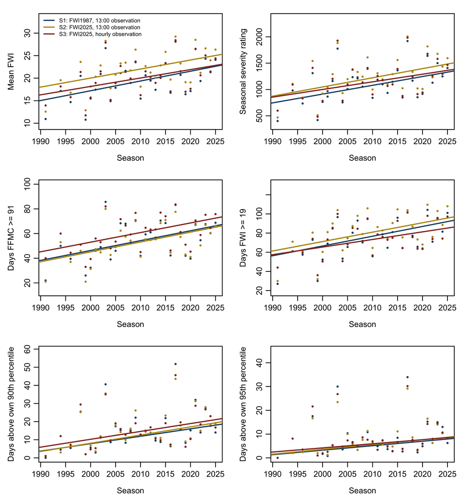

Figure 6: Seasonal metrics by season under the three series, pooled across stations as the station mean, with the Theil-Sen line for each series. The absolute and relative extreme-day counts are the panels the second question turned on, under the prediction that the absolute counts separate between series and the relative counts do not.

```r
show <- c("mean_fwi", "ssr", "n_ffmc_ge91", "n_fwi_ge19", "n_fwi_p90", "n_fwi_p95")
# Generous bottom margin and tightened axis title placement: at three rows on one
# page the default margin clips the x axis label against the panel below.
op <- par(mfrow = c(3, 2), mar = c(3.8, 4, 1.4, 1), mgp = c(2.4, 0.7, 0),
          cex = 0.68)
for (m in show) {
  ylab <- METRICS$label[match(m, METRICS$col)]
  rng <- range(metrics[[m]], na.rm = TRUE)
  plot(NA, xlim = range(metrics$year), ylim = rng, xlab = "Season", ylab = ylab,
       main = "")
  for (s in names(SERIES)) {
    d <- metrics[metrics$series == s, ]
    a <- aggregate(d[[m]], list(year = d$year), mean, na.rm = TRUE)
    points(a$year, a$x, col = cols[s], pch = 16, cex = 0.6)
    sl <- theil_sen(a$year, a$x)
    ic <- median(a$x - sl * a$year)
    abline(a = ic, b = sl, col = cols[s], lwd = 1.6)
  }
  if (m == show[1])
    legend("topleft", legend = unname(SERIES), col = cols, lwd = 1.6, bty = "n",
           cex = 0.7)
}
par(op)
```

```r
# The direction and strength of the trend picture, computed rather than eyeballed
# off the table, so the sentence below cannot say something the numbers do not.
tr_up <- sum(trends$slope > 0, na.rm = TRUE)
tr_n <- sum(is.finite(trends$slope))
tr_sig <- sum(trends$q < 0.05, na.rm = TRUE)
tr_sig_up <- sum(trends$q < 0.05 & trends$slope > 0, na.rm = TRUE)
# What the autocorrelation correction cost, in tests that would otherwise pass.
would_pass <- sum(p.adjust(trends$p_uncorrected, "BH") < 0.05, na.rm = TRUE)
infl <- median(trends$n_over_nstar, na.rm = TRUE)
# The two extremes among the extreme-day counts, which share the unit days per
# season, so that the paragraph names its highest and lowest cases rather than
# reporting only a count of how many passed.
day_tr <- trends[trends$metric %in% METRICS$col[METRICS$scheme != "level"], ]
hi <- day_tr[which.max(day_tr$slope), ]
lo <- day_tr[which.min(day_tr$slope), ]
name_case <- function(r) sprintf("%s under %s at %s (%+.2f days per season, q = %s)",
  METRICS$label[match(r$metric, METRICS$col)], unname(SERIES_PROSE[r$series]),
  station_prose(r$station),
  r$slope, ifelse(r$q < 0.001, "< 0.001", sprintf("%.3f", r$q)))
```

Figure 6 puts the three series side by side. The panels that bear on the second question are the two absolute-threshold counts against the two relative-threshold counts, because that contrast, and not the overall direction, is what the second question turned on.

## 4.5 Version Dependence

```r
CONTRASTS <- list(
  c("s1", "s2", "Version change, input held at 13:00"),
  c("s2", "s3", "Input resolution change, version held at FWI2025"),
  c("s1", "s3", "Operational migration, both changes")
)

diff_rows <- list()
for (cn in CONTRASTS) {
  for (i in seq_len(nrow(METRICS))) {
    m <- METRICS$col[i]
    for (stn in unique(metrics$station_name)) {
      a <- metrics[metrics$series == cn[1] & metrics$station_name == stn,
                   c("year", m)]
      b <- metrics[metrics$series == cn[2] & metrics$station_name == stn,
                   c("year", m)]
      w <- merge(a, b, by = "year", suffixes = c(".a", ".b"))
      names(w)[2:3] <- c("a", "b")
      if (nrow(w) < 15) next
      sd_ <- slope_difference(w)
      sd_$contrast <- cn[3]; sd_$metric <- m; sd_$station <- stn
      sd_$scheme <- METRICS$scheme[i]
      diff_rows[[length(diff_rows) + 1]] <- sd_
    }
  }
}
sdiff <- do.call(rbind, diff_rows)
if (is.null(sdiff) || !nrow(sdiff))
  stop("No station-series pair has the 15 paired seasons the bootstrap requires.")
# The family here is the eight metrics within one contrast at one station: one
# station's answer to one of the three questions the design asks.
sdiff$q <- ave(sdiff$p_two_sided, paste(sdiff$contrast, sdiff$station), FUN = fdr)
write.csv(sdiff, file.path(outputs, "slope-differences.csv"), row.names = FALSE)
```

```r
sd_tab <- do.call(rbind, lapply(
  split(sdiff, list(sdiff$contrast, sdiff$metric), drop = TRUE), function(d) {
    data.frame(
      Contrast = d$contrast[1],
      Scheme = d$scheme[1],
      Metric = METRICS$label[match(d$metric[1], METRICS$col)],
      Stations = nrow(d),
      `Median difference` = round(median(d$difference, na.rm = TRUE), 3),
      `Stations excluding zero` = sum(d$lower > 0 | d$upper < 0, na.rm = TRUE),
      `Stations q < 0.05` = sum(d$q < 0.05, na.rm = TRUE),
      check.names = FALSE)
  }))
sd_tab <- sd_tab[order(match(sd_tab$Contrast, vapply(CONTRASTS, `[`, "", 3)),
                       match(sd_tab$Metric, METRICS$label)), ]
rownames(sd_tab) <- NULL
fmt_tbl(sd_tab)
```

Table 9: Difference in Theil-Sen slope between series, by metric and contrast, pooled across stations as the median. Intervals are paired moving-block bootstrap percentile intervals over 4,000 resamples of blocks of consecutive seasons, which preserves both the dependence between series that share a weather record and the serial correlation within each. Stations excluding zero counts the stations whose own interval does not contain zero; the last column applies the Benjamini and Hochberg correction within each station’s eight-metric family for that contrast.

| Contrast | Scheme | Metric | Stations | Median difference | Stations excluding zero | Stations q < 0.05 |
| --- | --- | --- | --- | --- | --- | --- |
| Version change, input held at 13:00 | level | Mean FWI | 4 | -0.005 | 0 | 0 |
| Version change, input held at 13:00 | level | Seasonal severity rating | 4 | -0.085 | 0 | 0 |
| Version change, input held at 13:00 | level | Peak BUI | 4 | 0.146 | 0 | 0 |
| Version change, input held at 13:00 | absolute | Days FFMC >= 91 | 4 | -0.029 | 0 | 0 |
| Version change, input held at 13:00 | absolute | Days FWI >= 19 | 4 | -0.023 | 0 | 0 |
| Version change, input held at 13:00 | absolute | Days FWI >= 30 | 4 | -0.057 | 0 | 0 |
| Version change, input held at 13:00 | relative | Days above own 90th percentile | 4 | 0.044 | 0 | 0 |
| Version change, input held at 13:00 | relative | Days above own 95th percentile | 4 | 0.031 | 0 | 0 |
| Input resolution change, version held at FWI2025 | level | Mean FWI | 4 | 0.011 | 0 | 0 |
| Input resolution change, version held at FWI2025 | level | Seasonal severity rating | 4 | 0.923 | 0 | 0 |
| Input resolution change, version held at FWI2025 | level | Peak BUI | 4 | 0.247 | 0 | 0 |
| Input resolution change, version held at FWI2025 | absolute | Days FFMC >= 91 | 4 | -0.021 | 0 | 0 |
| Input resolution change, version held at FWI2025 | absolute | Days FWI >= 19 | 4 | -0.062 | 0 | 0 |
| Input resolution change, version held at FWI2025 | absolute | Days FWI >= 30 | 4 | -0.048 | 0 | 0 |
| Input resolution change, version held at FWI2025 | relative | Days above own 90th percentile | 4 | -0.038 | 0 | 0 |
| Input resolution change, version held at FWI2025 | relative | Days above own 95th percentile | 4 | -0.030 | 0 | 0 |
| Operational migration, both changes | level | Mean FWI | 4 | 0.005 | 0 | 0 |
| Operational migration, both changes | level | Seasonal severity rating | 4 | 1.006 | 0 | 0 |
| Operational migration, both changes | level | Peak BUI | 4 | 0.373 | 0 | 0 |
| Operational migration, both changes | absolute | Days FFMC >= 91 | 4 | -0.061 | 0 | 0 |
| Operational migration, both changes | absolute | Days FWI >= 19 | 4 | -0.101 | 0 | 0 |
| Operational migration, both changes | absolute | Days FWI >= 30 | 4 | -0.105 | 0 | 0 |
| Operational migration, both changes | relative | Days above own 90th percentile | 4 | 0.019 | 0 | 0 |
| Operational migration, both changes | relative | Days above own 95th percentile | 4 | 0.001 | 0 | 0 |

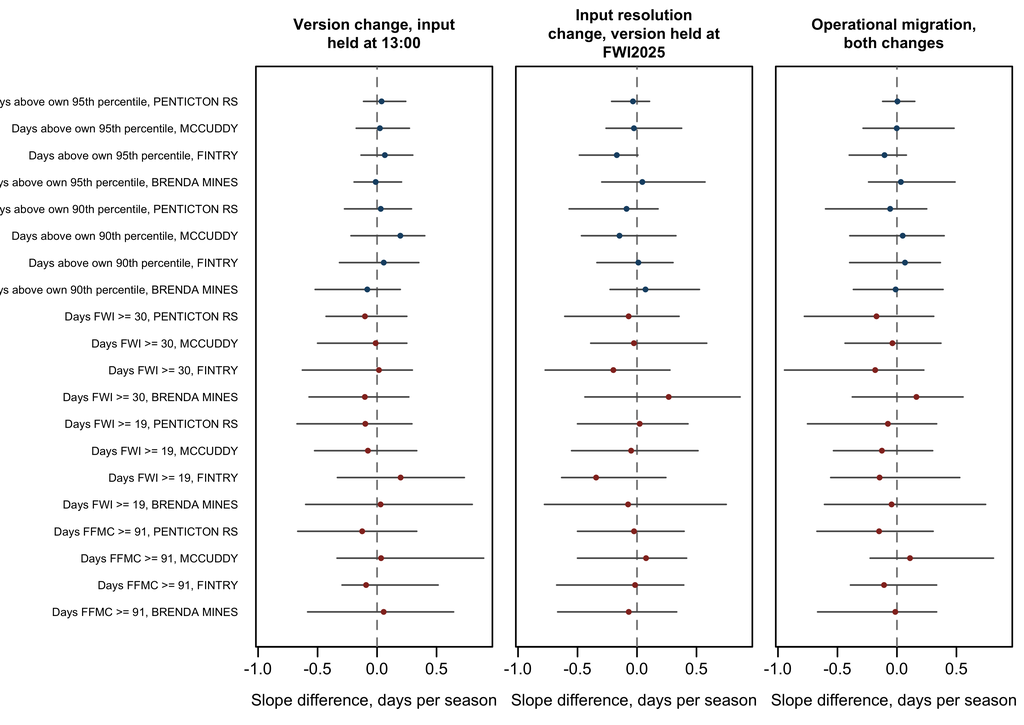

Figure 7: Difference in Theil-Sen slope between series for the five extreme-day counts, which all measure days per season and therefore share one axis. Points are station estimates, bars are paired moving-block bootstrap 95 per cent intervals over 4,000 resamples of blocks of consecutive seasons. Red marks the three absolute thresholds and blue the two thresholds internal to each series. The prediction under test is that the red points separate from zero and the blue ones do not. The three level metrics are omitted from this figure because the seasonal severity rating is measured on a scale two orders of magnitude larger and would compress everything else to a point; they are in the preceding table.

```r
# Only the metrics measured in days per season are drawn, so one x axis means the
# same thing everywhere on the figure. A common range across the three panels
# keeps the contrasts comparable, and the labels are drawn once on the left.
DAY_METRICS <- METRICS$col[METRICS$scheme %in% c("absolute", "relative")]
sd_plot <- sdiff[sdiff$metric %in% DAY_METRICS, ]
sd_plot$mi <- match(sd_plot$metric, METRICS$col)
xr <- range(c(sd_plot$lower, sd_plot$upper, 0), na.rm = TRUE)

op <- par(mfrow = c(1, 3), oma = c(0, 12.5, 0, 0), mgp = c(2.2, 0.6, 0), cex = 0.62)
for (k in seq_along(CONTRASTS)) {
  cn <- CONTRASTS[[k]]
  d <- sd_plot[sd_plot$contrast == cn[3], ]
  par(mar = c(4, 0.6, 3.4, 0.6))
  if (!nrow(d)) { plot.new(); next }
  d <- d[order(d$mi, d$station), ]
  y <- seq_len(nrow(d))
  plot(NA, xlim = xr, ylim = c(0.5, max(y) + 0.5), yaxt = "n",
       xlab = "Slope difference, days per season", ylab = "",
       main = paste(strwrap(cn[3], 24), collapse = "\n"), cex.main = 0.95)
  abline(v = 0, col = "grey50", lty = 2)
  segments(d$lower, y, d$upper, y, col = "grey35")
  points(d$difference, y, pch = 16, cex = 0.8,
         col = ifelse(d$scheme == "absolute", "#943126", "#1B4F72"))
  if (k == 1)
    axis(2, at = y, labels = paste0(METRICS$label[d$mi], ", ", d$station),
         las = 1, cex.axis = 0.7, tick = FALSE, line = -0.3, outer = TRUE)
}
par(op)
```

```r
# The hypothesis has a specific shape: absolute-threshold counts should separate
# between series and relative-threshold counts should not. That shape is scored
# here as two rates, so the sentence below reports what the numbers show rather
# than what the hypothesis predicted.
score <- function(contrast, scheme) {
  d <- sdiff[sdiff$contrast == contrast & sdiff$scheme == scheme, ]
  if (!nrow(d)) return(c(n = 0, sig = 0, rate = NA_real_, med = NA_real_))
  sig <- sum(d$q < 0.05, na.rm = TRUE)
  c(n = nrow(d), sig = sig, rate = 100 * sig / nrow(d),
    med = median(d$difference, na.rm = TRUE))
}
ver_label <- CONTRASTS[[1]][3]
inp_label <- CONTRASTS[[2]][3]
mig_label <- CONTRASTS[[3]][3]
sc <- rbind(
  `version, absolute`   = score(ver_label, "absolute"),
  `version, relative`   = score(ver_label, "relative"),
  `input, absolute`     = score(inp_label, "absolute"),
  `input, relative`     = score(inp_label, "relative"),
  `migration, absolute` = score(mig_label, "absolute"),
  `migration, relative` = score(mig_label, "relative"))
sc <- as.data.frame(sc)
write.csv(sc, file.path(outputs, "hypothesis-scoring.csv"))

# The resolution of the difference test, so that a null is readable. The half
# width of the bootstrap interval is the smallest difference this record could
# have separated from zero at each station and metric.
sdiff$halfwidth <- (sdiff$upper - sdiff$lower) / 2
res_abs <- median(sdiff$halfwidth[sdiff$scheme == "absolute"], na.rm = TRUE)
res_rel <- median(sdiff$halfwidth[sdiff$scheme == "relative"], na.rm = TRUE)
n_any_sig <- sum(sdiff$q < 0.05, na.rm = TRUE)

abs_rate <- sc["migration, absolute", "rate"]
rel_rate <- sc["migration, relative", "rate"]
verdict <- if (!is.finite(abs_rate) || !is.finite(rel_rate)) {
  "could not be scored"
} else if (abs_rate == 0 && rel_rate == 0) {
  "divergence under neither scheme, which the design had set as a refutation of the mechanism"
} else if (abs_rate > rel_rate) {
  "the pattern the mechanism predicted"
} else if (abs_rate > 0) {
  "divergence under both schemes, which the design had set as a refutation of the mechanism"
} else {
  "divergence under the percentile scheme alone, the opposite of the pattern the mechanism predicted"
}
```

Table 9 and Figure 7 decompose the difference. The prediction under test was that absolute-threshold counts would separate between series while relative-threshold counts would not, because the version change was expected to widen the tail without moving the level. Scored on the migration contrast, the one an agency faces, the absolute-threshold metrics gave a difference excluding zero at 0 per cent of station-metric combinations against 0 per cent for the relative-threshold metrics. That was divergence under neither scheme, which the design had set as a refutation of the mechanism.

The refutation holds to the resolution of the test. Across all 96 station, metric and contrast combinations, 0 gave a slope difference whose corrected interval excluded zero. The median half width of those intervals was 0.494 days per season for the absolute-threshold metrics and 0.327 for the relative ones, which over the 34 season window is 16.8 and 11.1 days respectively. A difference in trend smaller than that would not have been separated from zero here, so the refutation is of a slope divergence of at least that size. The level differences reported above were resolved comfortably, so what the version change demonstrably moved was where the distribution sits, not how fast it is moving.

Splitting the migration into its two halves, the version change alone gave 0 per cent of absolute-metric differences excluding zero and the input resolution change alone gave 0 per cent. The median differences are -0.044 and -0.038 per season respectively, against -0.092 for the two together, which is the additivity the design predicted if the two changes do not interact.

## 4.6 Summary Hour Sensitivity

```r
sens_cols <- c("n_ffmc_ge91", "n_ffmc_max_ge91", "n_fwi_ge19", "n_fwi_max_ge19")
have <- sens_cols %in% names(metrics)
if (all(have)) {
  sens <- do.call(rbind, lapply(split(metrics, metrics$series), function(d) data.frame(
    Series = unname(SERIES[d$series[1]]),
    `Days FFMC >= 91, fixed hour` = round(mean(d$n_ffmc_ge91, na.rm = TRUE), 1),
    `Days FFMC >= 91, daily maximum` = round(mean(d$n_ffmc_max_ge91, na.rm = TRUE), 1),
    `Days FWI >= 19, fixed hour` = round(mean(d$n_fwi_ge19, na.rm = TRUE), 1),
    `Days FWI >= 19, daily maximum` = round(mean(d$n_fwi_max_ge19, na.rm = TRUE), 1),
    check.names = FALSE)))
  rownames(sens) <- NULL
  fmt_tbl(sens)
} else {
  stop("seasonal-metrics.csv carries no daily maximum columns; re-run build_seasonal_metrics.py")
}
```

Table 10: Sensitivity of the absolute extreme-day counts to how an hourly series is reduced to a daily value. The fixed hour is 16:00 Local Standard Time, 17:00 local daylight time. The daily maximum takes the largest of the 24 hourly values, which must be at least as large and is reported only to bound the effect of the choice. FWI1987 produces one value per day and so appears once.

| Series | Days FFMC >= 91, fixed hour | Days FFMC >= 91, daily maximum | Days FWI >= 19, fixed hour | Days FWI >= 19, daily maximum |
| --- | --- | --- | --- | --- |
| S1: FWI1987, 13:00 observation | 57.2 |  | 78.1 |  |
| S2: FWI2025, 13:00 observation | 55.4 | 56.3 | 85.4 | 86.5 |
| S3: FWI2025, hourly observation | 61.9 | 72.7 | 77.8 | 92.7 |

Table 10 bounds the effect of the summary rule. Taking the daily maximum of 24 hourly values instead of one fixed hour raised every count in the two FWI2025 series and could not lower any of them, which is why it was not the primary, since part of that rise is the order statistic and not the System.

## 4.7 Ignition Skill

```r
mod_dat <- merge(basin, ign_daily, by = c("date", "year", "doy"))
mod_dat <- mod_dat[format(mod_dat$date, "%m") %in% c("05", "06", "07", "08", "09"), ]

SKILL_RESPONSES <- c("n_lightning_all", "n_total_all")

RESPONSES <- c(n_lightning_all = "Lightning, no size limit",
               n_person_all = "Person, no size limit",
               n_total_all = "All causes, no size limit",
               n_total_ge1ha = "All causes, at least 1 ha",
               n_total_ge4ha = "All causes, at least 4 ha")

ign_rows <- list()
for (r in names(RESPONSES)) {
  for (s in names(SERIES)) {
    dcol <- paste0(s, "_fwi")
    if (!dcol %in% names(mod_dat)) next
    m <- tryCatch(ignition_model(mod_dat, r, dcol, extra = "n_stations"),
                  error = function(e) NULL)
    if (is.null(m)) next
    # Held-out skill is computed only for the two responses the comparison
    # between series is read from. It refits the model once per season, so
    # running it on all five responses costs several hundred fits for numbers
    # the text does not use, and the cost is reported rather than hidden.
    sk <- if (r %in% SKILL_RESPONSES)
      tryCatch(loso_skill(mod_dat, r, dcol), error = function(e) NULL) else NULL
    # Wald interval on the danger coefficient rather than a profile likelihood
    # one. Profiling a negative binomial with a factor per season means refitting
    # once per grid point per model, which dominated the render, and the two
    # agree closely at this sample size. The interval is reported as Wald.
    se <- summary(m)$coefficients[".x", 2]
    ci <- coef(m)[".x"] + c(-1, 1) * qnorm(0.975) * se
    ign_rows[[length(ign_rows) + 1]] <- data.frame(
      response = r, series = s,
      coef = unname(coef(m)[".x"]),
      lower = ci[1], upper = ci[2],
      p = summary(m)$coefficients[".x", 4],
      theta = m$theta,
      loso_loglik = if (is.null(sk)) NA_real_ else sk$mean_loglik,
      n_days = nrow(mod_dat))
  }
}
ign_res <- do.call(rbind, ign_rows)
write.csv(ign_res, file.path(outputs, "ignition-models.csv"), row.names = FALSE)
```

```r
it <- data.frame(
  Response = unname(RESPONSES[ign_res$response]),
  Series = unname(SERIES[ign_res$series]),
  `Coefficient` = round(ign_res$coef, 4),
  `95% Wald interval` = sprintf("%.4f to %.4f", ign_res$lower, ign_res$upper),
  `Rate ratio per 10 FWI` = round(exp(10 * ign_res$coef), 2),
  `Held-out log likelihood` = round(ign_res$loso_loglik, 4),
  check.names = FALSE)
it <- it[order(match(it$Response, unname(RESPONSES)), it$Series), ]
rownames(it) <- NULL
fmt_tbl(it)
```

Table 11: Negative binomial models of daily ignition counts on daily basin Fire Weather Index, over the 1 May to 30 September window, with season as a fixed effect, two annual harmonics in day of year, and the number of contributing stations. The coefficient is the log change in expected count per unit of Fire Weather Index, identified from within-season variation only. Held-out log likelihood is the mean per day under leave-one-season-out refitting; larger is better, and the comparison between series rather than its absolute value is the quantity of interest. It is computed for the lightning and all-cause responses only, because those are the two the text compares and each refits the model once per season.

| Response | Series | Coefficient | 95% Wald interval | Rate ratio per 10 FWI | Held-out log likelihood |
| --- | --- | --- | --- | --- | --- |
| Lightning, no size limit | S1: FWI1987, 13:00 observation | 0.0161 | 0.0052 to 0.0269 | 1.17 | -0.4201 |
| Lightning, no size limit | S2: FWI2025, 13:00 observation | 0.0110 | -0.0005 to 0.0225 | 1.12 | -0.4206 |
| Lightning, no size limit | S3: FWI2025, hourly observation | 0.0099 | -0.0003 to 0.0200 | 1.10 | -0.4206 |
| Person, no size limit | S1: FWI1987, 13:00 observation | 0.0480 | 0.0421 to 0.0539 | 1.62 |  |
| Person, no size limit | S2: FWI2025, 13:00 observation | 0.0489 | 0.0428 to 0.0550 | 1.63 |  |
| Person, no size limit | S3: FWI2025, hourly observation | 0.0412 | 0.0360 to 0.0465 | 1.51 |  |
| All causes, no size limit | S1: FWI1987, 13:00 observation | 0.0332 | 0.0289 to 0.0375 | 1.39 | -1.1637 |
| All causes, no size limit | S2: FWI2025, 13:00 observation | 0.0329 | 0.0283 to 0.0374 | 1.39 | -1.1664 |
| All causes, no size limit | S3: FWI2025, hourly observation | 0.0287 | 0.0247 to 0.0327 | 1.33 | -1.1672 |
| All causes, at least 1 ha | S1: FWI1987, 13:00 observation | 0.0706 | 0.0585 to 0.0827 | 2.03 |  |
| All causes, at least 1 ha | S2: FWI2025, 13:00 observation | 0.0702 | 0.0582 to 0.0823 | 2.02 |  |
| All causes, at least 1 ha | S3: FWI2025, hourly observation | 0.0670 | 0.0568 to 0.0772 | 1.95 |  |
| All causes, at least 4 ha | S1: FWI1987, 13:00 observation | 0.0846 | 0.0673 to 0.1018 | 2.33 |  |
| All causes, at least 4 ha | S2: FWI2025, 13:00 observation | 0.0826 | 0.0660 to 0.0992 | 2.28 |  |
| All causes, at least 4 ha | S3: FWI2025, hourly observation | 0.0845 | 0.0706 to 0.0984 | 2.33 |  |

```r
best <- ign_res[ign_res$response == "n_lightning_all", ]
best <- best[order(-best$loso_loglik), ]
skill_gap <- diff(range(best$loso_loglik))

# Does the danger term survive at every size threshold, and does it separate the
# lightning series from the person-caused control? The control matters: human
# ignition tracks population and access, so a danger signal appearing equally in
# both would point to a shared confounder rather than to fuel moisture.
sig_by_response <- tapply(ign_res$p, ign_res$response, function(p) sum(p < 0.05))
rr <- function(resp, s) {
  v <- ign_res$coef[ign_res$response == resp & ign_res$series == s]
  if (!length(v)) NA_real_ else exp(10 * v)
}
rr_light <- rr("n_lightning_all", "s3")
rr_person <- rr("n_person_all", "s3")
```

Table 11 gives the models. The danger term was positive and significant at the conventional level for 13 of the 15 response and series combinations, identified entirely from day-to-day variation inside a season.

The response that carried the signal was not the one expected. Ten units of Fire Weather Index multiplied the expected daily person-caused count by 1.51 and the expected daily lightning count by 1.10, and it was the lightning term, not the person one, that failed to separate from zero. That is the reverse of the expected order until the two mechanisms are separated. A person-caused ignition needs an ignition source and a receptive fuel bed; the sources are close to constant from day to day, so whether one becomes a reported fire is largely a question of fuel moisture, which is what the index measures. A lightning-caused ignition needs a strike, and strikes are not in this model. Lightning ignitions also arrive in bursts, one storm producing many fires, which was visible in the fitted dispersion parameter, at 0.11 for the lightning series against 2.97 for the person-caused one, where a smaller value means more clustering. The person-caused series was carried as a control against a shared confounder and turned out to be the more informative response. No lightning-strike record covering the whole period was obtained, and that omission, rather than an absence of any relationship, is the most likely reason the lightning term is weak, since Magnussen & Taylor (2012), who had strike data, predicted the daily number of lightning fires in British Columbia better than the number of human-caused ones. A second reason is timing. A lightning ignition can smoulder in the duff before it is found, and Coogan, Cannon, & Flannigan (2025) noted in agency fire records “a lag between the time a fire started and the time it was detected” (Coogan et al., 2025, p. 16), so a lightning fire dated to one day may have been ignited under the danger of an earlier one.

The comparison the third question actually asked was between series, and it was small. On held-out seasons the three differed by 0.0005 in mean log likelihood per day, with FWI1987 on the 13:00 observation first at -0.4201 and FWI2025 on hourly weather last at -0.4206. Over the 4,743 days in the window that was a total difference of about 2.3 log likelihood units, which is not a basis for preferring one series over another. Figure 8 shows the fitted and observed relationship, in which the three curves are separated horizontally by the same level differences the threshold table reports as percentiles, and vertically by very little.

Table 12 tests whether that relationship changed across the record. The interaction between the danger term and season number is the quantity of interest, and it is reported with the caveat the record forces, that a between-season change is exactly what the ignition record’s own non-stationarity could imitate.

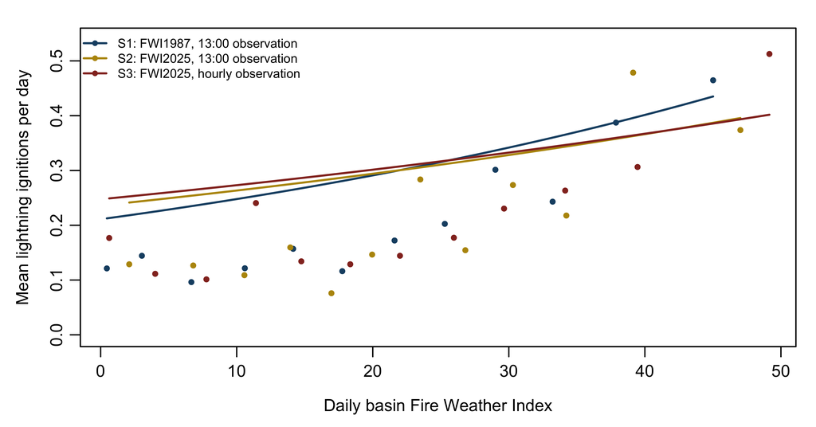

Figure 8: Observed and fitted daily lightning ignition rate against daily basin Fire Weather Index under the three series. Points are the observed mean count in equal-count bins of the danger value; lines are the fitted negative binomial rate at the mean season and the mid-season day of year. The horizontal offsets between the three curves are the same level differences that the threshold table reports as percentiles.

```r
# Two things are drawn and they are different. The points are the observed mean
# daily count in equal-count bins of the danger value, so each rests on the same
# number of days and the right hand tail is not one noisy observation. The curves
# are the fitted negative binomial rate, refitted here for the lightning response,
# evaluated at the mean fitted season effect and at mid-season day of year, which
# is what the model says a typical season looks like.
binned <- lapply(names(SERIES), function(s) {
  x <- mod_dat[[paste0(s, "_fwi")]]
  y <- mod_dat$n_lightning_all
  ok <- is.finite(x) & is.finite(y)
  br <- unique(quantile(x[ok], seq(0, 1, length.out = 13), na.rm = TRUE))
  bin <- cut(x[ok], br, include.lowest = TRUE)
  data.frame(x = tapply(x[ok], bin, mean), y = tapply(y[ok], bin, mean))
})
names(binned) <- names(SERIES)

mid_doy <- median(mod_dat$doy)
fitted_curve <- function(s) {
  m <- tryCatch(ignition_model(mod_dat, "n_lightning_all", paste0(s, "_fwi"),
                               extra = "n_stations"),
                error = function(e) NULL)
  if (is.null(m)) return(NULL)
  co <- coef(m)
  cf <- function(nm) if (nm %in% names(co) && is.finite(co[[nm]])) co[[nm]] else 0
  yr_terms <- co[grepl("^\\.year", names(co))]
  grid <- seq(min(binned[[s]]$x, na.rm = TRUE), max(binned[[s]]$x, na.rm = TRUE),
              length.out = 60)
  eta <- cf("(Intercept)") + mean(c(0, yr_terms), na.rm = TRUE) + cf(".x") * grid +
    cf(".s1") * sin(2 * pi * mid_doy / 365.25) +
    cf(".c1") * cos(2 * pi * mid_doy / 365.25) +
    cf(".s2") * sin(4 * pi * mid_doy / 365.25) +
    cf(".c2") * cos(4 * pi * mid_doy / 365.25) +
    cf("n_stations") * mean(mod_dat$n_stations)
  data.frame(x = grid, y = exp(eta))
}
curves <- lapply(names(SERIES), fitted_curve)
names(curves) <- names(SERIES)

op <- par(mar = c(4, 4, 1.4, 1), mgp = c(2.4, 0.7, 0), cex = 0.8)
plot(NA,
     xlim = range(unlist(lapply(binned, `[[`, "x")), na.rm = TRUE),
     ylim = c(0, max(unlist(lapply(binned, `[[`, "y")), na.rm = TRUE) * 1.05),
     xlab = "Daily basin Fire Weather Index",
     ylab = "Mean lightning ignitions per day")
for (s in names(SERIES)) {
  points(binned[[s]]$x, binned[[s]]$y, col = cols[s], pch = 16, cex = 0.8)
  if (!is.null(curves[[s]])) lines(curves[[s]]$x, curves[[s]]$y, col = cols[s], lwd = 1.6)
}
legend("topleft", legend = unname(SERIES), col = cols, lwd = 1.6, pch = 16,
       bty = "n", cex = 0.75)
par(op)
```

```r
# Is the danger to ignition relationship stationary? The test is an interaction
# between the danger term and season number. Season is already a fixed effect,
# so the interaction asks whether the within-season slope changes over the
# record, which is a different question from whether the intercept does.
stat_rows <- list()
for (r in c("n_lightning_all", "n_total_all")) {
  for (s in names(SERIES)) {
    dcol <- paste0(s, "_fwi")
    d <- mod_dat
    d$.yc <- d$year - mean(d$year)
    m <- tryCatch(ignition_model(d, r, dcol, extra = "I(.x * .yc)"),
                  error = function(e) NULL)
    if (is.null(m)) next
    cf <- summary(m)$coefficients
    nm <- grep("I\\(.x", rownames(cf), value = TRUE)[1]
    stat_rows[[length(stat_rows) + 1]] <- data.frame(
      response = r, series = s,
      interaction = cf[nm, 1], se = cf[nm, 2], p = cf[nm, 4])
  }
}
stationarity <- do.call(rbind, stat_rows)
write.csv(stationarity, file.path(outputs, "stationarity-tests.csv"),
          row.names = FALSE)
```

```r
st <- data.frame(
  Response = unname(RESPONSES[stationarity$response]),
  Series = unname(SERIES[stationarity$series]),
  `Interaction` = signif(stationarity$interaction, 3),
  `Standard error` = signif(stationarity$se, 3),
  `p` = signif(stationarity$p, 3),
  check.names = FALSE)
fmt_tbl(st)
```

Table 12: Test of whether the within-season relationship between fire danger and daily ignition count changes across the record. The reported term is the interaction between the Fire Weather Index and centred season number; a positive value would mean more ignitions per unit danger in later seasons. Season is already a fixed effect, so this asks about the slope and not the level.

| Response | Series | Interaction | Standard error | p |
| --- | --- | --- | --- | --- |
| Lightning, no size limit | S1: FWI1987, 13:00 observation | -0.0000337 | 0.000512 | 0.947 |
| Lightning, no size limit | S2: FWI2025, 13:00 observation | 0.0001930 | 0.000537 | 0.720 |
| Lightning, no size limit | S3: FWI2025, hourly observation | -0.0000706 | 0.000466 | 0.880 |
| All causes, no size limit | S1: FWI1987, 13:00 observation | -0.0000276 | 0.000217 | 0.899 |
| All causes, no size limit | S2: FWI2025, 13:00 observation | 0.0000828 | 0.000227 | 0.715 |
| All causes, no size limit | S3: FWI2025, hourly observation | 0.0000213 | 0.000196 | 0.913 |

# 5 Discussion

```r
# The level shifts each change produces, per season, on the two absolute-threshold
# counts. Sign matters here and is computed, not asserted: the two changes do not
# necessarily push the same way.
lvl <- function(metric, a, b) {
  mean(metrics[[metric]][metrics$series == b], na.rm = TRUE) -
    mean(metrics[[metric]][metrics$series == a], na.rm = TRUE)
}
shift <- data.frame(
  metric = c("Days FFMC >= 91", "Days FWI >= 19"),
  version = c(lvl("n_ffmc_ge91", "s1", "s2"), lvl("n_fwi_ge19", "s1", "s2")),
  input = c(lvl("n_ffmc_ge91", "s2", "s3"), lvl("n_fwi_ge19", "s2", "s3")),
  migration = c(lvl("n_ffmc_ge91", "s1", "s3"), lvl("n_fwi_ge19", "s1", "s3"))
)
write.csv(shift, file.path(outputs, "level-shifts.csv"), row.names = FALSE)

same_sign <- function(i) sign(shift$version[i]) == sign(shift$input[i])
ffmc_word <- if (same_sign(1)) "compound" else "oppose one another"
fwi_word <- if (same_sign(2)) "compound" else "oppose one another"

# Where the two changes oppose, what survives is the residual, and how much
# survives is the whole point. Cancellation is measured as the migration shift
# relative to the larger of the two component shifts.
residual <- function(i) {
  abs(shift$migration[i]) / max(abs(shift$version[i]), abs(shift$input[i]))
}
ffmc_res <- residual(1); fwi_res <- residual(2)
bigger <- function(i) if (abs(shift$version[i]) > abs(shift$input[i]))
  "the version change" else "the input resolution change"
```

## 5.1 Version and Input

```r
sh <- data.frame(
  Metric = shift$metric,
  `Version change` = sprintf("%+.1f", shift$version),
  `Input resolution change` = sprintf("%+.1f", shift$input),
  `Migration, both` = sprintf("%+.1f", shift$migration),
  check.names = FALSE)
fmt_tbl(sh)
```

Table 13: How each change moves the seasonal count of extreme days, in days per season averaged over kept station-seasons. The version column is FWI1987 to FWI2025 at fixed 13:00 input; the input column is the 13:00 pathway to observed hourly weather at fixed FWI2025; the migration column is the two together, and equals their sum by construction, so the signs of the two components are what the table shows.

| Metric | Version change | Input resolution change | Migration, both |
| --- | --- | --- | --- |
| Days FFMC >= 91 | -1.8 | +6.5 | +4.7 |
| Days FWI >= 19 | +7.3 | -7.6 | -0.3 |

The reason a straight comparison of FWI1987 against FWI2025 would have been uninterpretable is in Table 13, and it is not that the two changes were small, because they were large and they pointed opposite ways.

On the count of days above a Fine Fuel Moisture Code of 91, the version change moved the seasonal count by -1.8 days and the input resolution change by +6.5, so the two oppose one another, and the input resolution change won, the migration netting +4.7 days. On the count of days above a Fire Weather Index of 19 the same two changes moved it by +7.3 and -7.6 days, so there they oppose one another too, but almost exactly, the migration netting -0.3 days, 4 per cent of the larger component.

That is the case for the three-series design. A study that had computed FWI1987 on noon data and FWI2025 on hourly data would have seen +4.7 days on one metric and -0.3 on the other, and would have concluded that the update barely touched the Fire Weather Index count while shifting the Fine Fuel Moisture Code count. Both readings would be wrong about the mechanism, because the Fire Weather Index count was not stable through nothing happening to it but because a +7.3 day version effect and a -7.6 day input effect happened to land on top of one another in this basin. Cancellation of that kind is a coincidence of two large effects at one place rather than robustness, and there is no reason for it to hold at a site with a different diurnal range.

The few studies that varied one element of a fire danger calculation on a fixed record found effects of the same kind. On thirteen years of station data from Camden, New South Wales, Matthews (2009) found that the differences in structure between three fire danger systems partly cancelled once each used its own observation time and moisture sub-models, which is the cancellation found here for days above a Fire Weather Index of 19, where a +7.3 day version effect and a -7.6 day input effect netted -0.3 days. On the Iberian Peninsula, Herrera et al. (2013) found that daily mean inputs missed 45 per cent of the extreme days in the series computed from 12 UTC inputs, and here replacing the reconstructed diurnal curve with observed hourly weather moved the count of days above a Fine Fuel Moisture Code of 91 by +6.5 days per season, so in both records the way the weather was supplied to the calculation moved the extreme-day count by an amount comparable to a change of system. Rodell et al. (2024) found in western North America that hourly Fire Weather Index values sampled at noon were biased low against the daily index because noon did not coincide with peak fire behaviour, which is the reason the daily value here was taken at 17:00 local daylight time and the daily maximum was reported only as a bound. None of those studies followed a trend through the change, so the result here, a level shift with no slope divergence this record could resolve, could not be compared with any of them.

This is the part of the update that is genuinely new rather than a change of scale, because a daily index cannot say when the peak arrives or how long it lasts, and those are the two quantities an initial attack decision actually needs. The finding here was not that the hourly series predicted ignitions better, because it was barely distinguishable on that, but that it answered a question the daily series cannot be asked.

The small difference in ignition skill between the three series agreed with comparisons of danger indices against fire records elsewhere. In Mediterranean France, Castel-Clavera et al. (2025) found the Fire Weather Index the most skilful of the indices tested but found that no index alone was sufficient to rate fire activity without spatial and seasonal effects. The ignition models here carried the seasonal effect as two annual harmonics in day of year, with season as a factor, whereas a model of one basin mean had no spatial effect to carry. Skill on occurrence also did not carry over to area, because across 11 regions from the European Alps to the Mediterranean basin Bekar et al. (2023) found that models with a high area under the receiver operating characteristic curve for fire occurrence could still perform poorly on burned area, and Joaquín Bedia et al. (2015) found across the world’s major biomes a saturation threshold in the response of area burned to fire weather, above which area burned was insensitive to further increases, so the ignition counts tested here could not show whether the three series would differ on area burned. A more direct test of the halved time lag would score both versions against measured litter moisture, as Schunk, Wastl, Leuchner, & Menzel (2017) did to rank danger indices in eight forest stands in southern Germany, where fire records were too sparse for that purpose.

## 5.2 Published Trends

The slope prediction failed. Under neither thresholding scheme did the migration change an estimated trend at any station, the outcome the design had set as refuting the mechanism, and the refutation holds to a resolution of about 16.8 days over the window. The practical consequence for the published record therefore rests on the level result alone, and is narrow and specific. Trends reported as percentile exceedances, where the threshold is computed inside the series being trended, are largely insulated from the version change, because the threshold moves with the distribution. Trends reported as counts above a fixed danger class are not, and neither are seasonal severity ratings, which accumulate a transform of the index level over a season and therefore inherit any level shift. Fixed classes were already uncertain across regions before any version change, since Papagiannaki, Giannaros, Lykoudis, Kotroni, & Lagouvardos (2020) found that the Fire Weather Index class thresholds of the European Forest Fire Information System were too low for Greece and that thresholds fitted to Greek fire records predicted wildfire danger significantly better. That insulation is from the version and not from the reference period. Dunn & Morice (2022) found that warm-day trends computed from the same data over the same years changed by about 25 to 50 per cent when the percentile reference period moved, and X. Zhang et al. (2005) showed that counts outside a base period are biased upward unless the rates inside it are bootstrapped, so a percentile trend is portable across the version change only when its reference period is stated, held fixed and treated for that bias.

Nothing here says the published trends are wrong, only that they are statements about FWI1987, that restating them under FWI2025 will change some of them, and that the size of the change depends on how the metric was defined rather than on the weather. Anyone re-expressing a historical trend in the new system’s units should recompute the whole record rather than splice, and should say which metric family the result belongs to.

## 5.3 Limitations

```r
# The quantitative limits statement. For each metric the minimum detectable trend
# is the slope this record could resolve at 80 per cent power, given the residual
# spread of that metric about its own Theil-Sen line. Expressing it over the whole
# window rather than per season is what makes it legible: a slope of 0.3 days per
# season is 10 days over 34 seasons, and the second number is the one a reader can
# judge.
lim <- do.call(rbind, lapply(split(trends, trends$metric), function(d) {
  mdt <- median(d$mdt, na.rm = TRUE)
  data.frame(
    Metric = METRICS$label[match(d$metric[1], METRICS$col)],
    `Median observed slope` = round(median(d$slope, na.rm = TRUE), 3),
    `Minimum detectable slope` = round(mdt, 3),
    `Minimum detectable change over the window` =
      round(mdt * (yr_last - yr_first), 2),
    `Observed change over the window` =
      round(median(d$slope, na.rm = TRUE) * (yr_last - yr_first), 2),
    check.names = FALSE)
}))
lim <- lim[order(match(lim$Metric, METRICS$label)), ]
rownames(lim) <- NULL
write.csv(lim, file.path(outputs, "detectability.csv"), row.names = FALSE)
```

```r
fmt_tbl(lim)
```

Table 14: What a window of this length can and cannot resolve. The minimum detectable slope is the trend at which a two-sided test at alpha 0.05 would reach 80 per cent power given the residual spread of that metric about its own Theil-Sen line, adjusted for the efficiency of the Theil-Sen estimator relative to least squares and inflated for lag-one autocorrelation of the residuals. A metric whose observed change is smaller than its minimum detectable change is not evidence of no trend; it is evidence that this record cannot see one of that size.

| Metric | Median observed slope | Minimum detectable slope | Minimum detectable change over the window | Observed change over the window |
| --- | --- | --- | --- | --- |
| Mean FWI | 0.180 | 0.266 | 9.04 | 6.14 |
| Seasonal severity rating | 13.486 | 23.245 | 790.32 | 458.54 |
| Peak BUI | 1.740 | 5.206 | 177.01 | 59.17 |
| Days FFMC >= 91 | 0.741 | 0.934 | 31.77 | 25.19 |
| Days FWI >= 19 | 0.739 | 1.341 | 45.58 | 25.11 |
| Days FWI >= 30 | 0.625 | 1.119 | 38.06 | 21.25 |
| Days above own 90th percentile | 0.372 | 0.778 | 26.45 | 12.66 |
| Days above own 95th percentile | 0.149 | 0.517 | 17.57 | 5.07 |

Table 14 is the quantitative form of what this study cannot say. It matters because a null result and an underpowered result read identically in a table of p values and are entirely different claims. Where a metric’s observed change over the window fell below its minimum detectable change, the correct statement is that a trend of that size would not have been seen here, not that there is none.

Six further limits are structural rather than statistical. First, the study covered one basin, and only its Canadian part. Everything here is the Okanagan watershed group, and the United States portion of the basin was excluded because neither the ignition record nor the weather record crosses the border. Whether the version effect found here has the same size elsewhere is untested, and there is a specific reason to expect it not to, because the mechanism runs through the diurnal cycle, and the Okanagan’s is unusually wide. Second, the study detected change and did not attribute it. Nothing here separated a change in fire danger from its causes, no claim was made about anthropogenic forcing, and none should be read in, because attribution requires a comparison against a world without the forcing that this design did not construct (Kirchmeier-Young et al., 2019). Third, no oscillation term entered any model. The El Niño Southern Oscillation and the Pacific Decadal Oscillation modulate fire season severity in interior British Columbia (Meyn, Taylor, et al., 2010), although Tan, Chen, Gan, Liu, & Chen (2019) found that neither had contributed to wildfire weather in western Canada and that spring warming and drying there since 1871 could not be attributed to common teleconnections, and in another mountain region Mamgain, Roy, & Karnatak (2026) found fire danger elevated in El Niño years and reduced in La Niña years from 2000 to 2024. A window that begins and ends in different phases carries a biased slope regardless of estimator. No oscillation index was included, and including one would require choosing the index and the lag from the literature on interior British Columbia fire seasons before the record was examined. The absolute trends under the first question therefore carry that bias, whereas the comparison between series under the second does not, because all three series see the same oscillation. Fourth, fuel was held fixed. Fuel typing did not vary through time in this design, so nothing here distinguished a danger effect from fuel accumulation, which is a stated boundary and not a gap to be filled with the same data. The boundary matters for reading a danger trend as a fire trend, because Wastl et al. (2012) found meteorological fire danger rising in Bavaria while the number of fires and the area burned fell, and Zhao, Zhang, Zhen, Wang, & Yin (2025) found across mid to high northern latitudes from 1982 to 2018 that rising flammability increased wildfire in fuel-rich forests but decreased it where water deficits had reduced fuel. Fifth, four analysis choices, the season window, the coverage threshold, the reference period and the daily summary hour, were set with the data in view rather than fixed in advance, so the absolute trends carry that freedom, whereas the comparison between series does not, because all three series ran through the same choices and a choice that moved one moved all three. Sixth, the season window was fixed. A 1 May to 30 September window measures danger inside a season of fixed length and cannot register a season that lengthens at either end, so if the true season lengthened, the counts inside the window rose by less than whole-season counts would have, and trends in window counts understate trends in the season. Four routes would recover the season from this basin, each at a cost. The first is a year-round climate station of the kind C. Hanes et al. (2020) used for winter precipitation, driving the temperature rule of Lawson & Armitage (2008) and overwintering the Drought Code, at the cost of dating the season from a valley site rather than from the fire weather stations. The second is the danger-series definition of Jolly et al. (2015) applied inside a wider fixed window, which needs the stations to be reporting before the first day above half the danger range and fails in any season they were not. The third is the fire-based definitions of Westerling (2016) and Granville et al. (2026), which the basin’s ignition record cannot support after 2000 because its dating completeness fell, as Section 2 showed. The fourth is a reanalysis start date, which carries the grid-cell caveat set out below. The first route is the one this record could adopt, because it would also replace the Drought Code restart that McElhinny et al. (2020) showed changes spread-day counts, and it would enter all three series alike, leaving the comparison between them intact.

The obvious way to extend this study is to run it on a reanalysis, which would buy the whole basin, a longer record and every other basin in Canada at once. The reason it was not done here is stated, because it is the same reason the extension is not straightforward.

Pathway A of FWI2025 needs the timing of rainfall within the day. That is the input the halved fine fuel time lag and the six hour canopy interception reset both act on, and it is the input a once-daily observation cannot supply. Very few long records carry genuinely hourly precipitation. This basin has one because the BC Wildfire Service network was built to run a fire danger system, and its archive preserves the hourly rain gauge alongside the computed codes. A reanalysis does supply hourly precipitation, but it supplies a modelled one, and Canadian Forest Service Fire Danger Group (2025) states the caveat plainly in Appendix C-1, that “numerical weather model outputs are not strictly the same as point observations of weather from a weather station”, and “At the grid cell scale, outputs from numerical models typically represent what can be thought of as average conditions across that cell.” Evaluations of gridded fire danger products bear that caveat out. J. Bedia et al. (2012) found that the NCEP, ERA-40 and ERA-Interim reanalyses all tended to underestimate the Fire Weather Index computed at seven Spanish weather stations, Robert D. Field (2020) found that components computed from MERRA-2 were in general biased low against a global station network, Vitolo et al. (2020) found the largest biases of the ERA5 fire danger reanalysis in mountainous areas, and Silver & Lundquist (2025) found that station and reanalysis records in the mountains of Colorado disagreed on whether a fire weather trend existed at all. A cell average is exactly the quantity whose diurnal range is smallest, and the diurnal range is the mechanism under test here. A reanalysis-driven version comparison would therefore be biased towards finding no difference, in a basin where the relief runs through more than two kilometres.

That is a statement about this comparison, not about reanalysis in general. For estimating the level or the trend of fire danger over a region, a reanalysis is the right instrument and a five station network is not. The two questions want different data, and conflating them is how a study of one gets answered with the instrument for the other.

# 6 Conclusions

```r
# The four numbers the conclusions rest on, pulled from the objects above rather
# than retyped.
c_days_gap <- d_s3 - d_s1
c_pct_gap <- 100 * c_days_gap / d_s1
c_dur <- if (exists("ct") && nrow(ct) == 2) {
  ct$`Mean burning window (h)`[grepl("S3", ct$Series)] -
    ct$`Mean burning window (h)`[grepl("S2", ct$Series)]
} else NA_real_
c_abs_rate <- sc["migration, absolute", "rate"]
c_rel_rate <- sc["migration, relative", "rate"]
```

Over 31 seasons in the Okanagan basin the 2025 update to the Fire Weather Index System left the middle of the distribution close to where it was and moved the tail, so a level was portable across the two versions and a count of extreme days was not. The threshold the update’s own report offers as the example of continuity, a Fine Fuel Moisture Code of 91, selected 4.7 more days per season under the new system driven by hourly weather than under the old one, a change of 8 per cent in a quantity that is routinely trended.

The slope prediction failed. Under absolute thresholds the migration changed the estimated trend at 0 per cent of station-metric combinations and under thresholds internal to each series at 0 per cent, divergence under neither scheme, which the design had set as a refutation of the mechanism, at a resolution of about 16.8 days over the window, so the refutation is of a slope divergence of at least that size. What was comfortably visible was the level difference, and a level difference is enough to break a comparison between a number published under the old system and a number computed under the new one, even where both are trending at the same rate.

The practical recommendation follows from the level result and costs nothing to adopt. Fire danger trends should be reported as exceedances of a percentile computed inside the series being reported, over a stated and fixed reference period and with the base-period bias removed, not as counts above a fixed danger class, and the report should state which, because a percentile threshold moves with the distribution it is drawn from and is therefore portable across the version change, whereas a fixed class boundary is not.

For predicting where fires start, the three series were close to interchangeable in this basin. What the hourly system added was not accuracy in the daily number but information the daily number cannot carry, namely when in the day the peak arrives and how long the burning window stays open, and on that second quantity the observed hourly weather and the reconstructed diurnal curve disagreed by 3.7 hours per day. An agency migrating to FWI2025 with only a 13:00 observation to feed it would inherit that disagreement without any sign of it in the output.

None of this is attribution. It is a measurement of how much a published Canadian fire danger trend depends on the arithmetic that produced it, made in one basin where the weather record was good enough to ask.

# Author Contributions

S.M. conceived and designed the study, retrieved and processed the data, wrote the analysis code, ran the analysis and wrote the manuscript.

# Funding

Not yet declared.

# Data Availability

The hourly fire weather observations are public at the BC Wildfire Service Weather Data Mart (BC Wildfire Service, 2026c) and the incident record, the station locations and the basin boundary at the BC Data Catalogue (BC Wildfire Service, 2026a, 2026b; GeoBC Branch, 2026b), all under the licences stated at those sources. The FWI2025 calculation used the Canadian Forest Service reference implementation (Canadian Forest Service Fire Danger Group, 2026) unmodified. The derived tables, the FWI1987 implementation, the retrieval and analysis code, and the source of this document, from which every number in it is computed, are available from the author and will be archived with a persistent identifier on acceptance.

# Conflicts of Interest

Not yet declared.

# Abstract

```r
# Composed with sprintf from objects the document already computed. Nothing here
# is typed. If a result changes, this paragraph changes with it or the render
# fails, which is the point.
pull <- function(d, s, col) d[[col]][grepl(toupper(s), d$Series)]

abs_ffmc <- subset(tp, Component == "FFMC" & Threshold == 91)
abs_p <- vapply(c("S1", "S2", "S3"), function(s)
  pull(abs_ffmc, s, "Percentile of threshold"), numeric(1))
abs_d <- vapply(c("S1", "S2", "S3"), function(s)
  pull(abs_ffmc, s, "Days per season above"), numeric(1))

# The migration contrast, absolute against relative thresholding.
mig_rows <- sdiff[sdiff$contrast == mig_label, ]
abs_mig <- mig_rows[mig_rows$scheme == "absolute", ]
rel_mig <- mig_rows[mig_rows$scheme == "relative", ]
n_abs_sig <- sum(abs_mig$lower > 0 | abs_mig$upper < 0, na.rm = TRUE)
n_rel_sig <- sum(rel_mig$lower > 0 | rel_mig$upper < 0, na.rm = TRUE)

# Ignition skill, on the lightning series.
lig <- ign_res[ign_res$response == "n_lightning_all", ]
lig <- lig[order(-lig$loso_loglik), ]

abstract_text <- sprintf(
"Almost every published Canadian fire danger trend is expressed in the units of
the 1987 Fire Weather Index System, which the Canadian Forest Service replaced in
2025 with a version that changed the calculation and the resolution of the
weather driving it at once, so a straight comparison cannot attribute a
difference to either change, and no study has separated them. This study
computed three danger series from one hourly weather record (%d fire weather
stations, %s station-seasons, %d fire seasons, %d to %d, Canadian Okanagan basin,
British Columbia), FWI1987 from the 13:00 observation, FWI2025 from the same
observation through the legacy pathway, and FWI2025 from observed hourly weather.
Trends were estimated with the Theil-Sen slope and the Mann-Kendall test under
the Hamed and Rao correction, series differences were bootstrapped over blocks of
consecutive seasons, and daily ignition counts were modelled as negative binomial with
season as a fixed effect. The comparability claimed by the 2025 report held for
levels and failed for tails, in that a Fine Fuel Moisture Code of 91 sat at percentile
%.1f of the legacy series and percentile %.1f of the hourly series, %.0f
against %.0f days per season. Of %d station-metric combinations under absolute
thresholds, %d gave a migration slope difference excluding zero, against %d of
%d under percentile thresholds, at a resolution of about %.1f days over the
window, which refuted the predicted slope divergence at that resolution, so the
version change moved the level and left no slope difference the record could resolve. On
held-out seasons the three series differed by %.4f in mean log likelihood per
day, %s. Fire danger trends should therefore be reported as percentile
exceedances with the version of the System stated, because a fixed danger class
did not carry across the change and a percentile threshold did.\n",
  n_stations_kept, format(n_kept, big.mark = ","), n_seasons, yr_first, yr_last,
  abs_p[["S1"]], abs_p[["S3"]], abs_d[["S1"]], abs_d[["S3"]],
  nrow(abs_mig), n_abs_sig, n_rel_sig, nrow(rel_mig),
  res_abs * (yr_last - yr_first),
  diff(range(lig$loso_loglik)),
  sprintf("with %s ranking first", unname(SERIES_PROSE[lig$series[1]]))
)
cat(abstract_text)
```

Almost every published Canadian fire danger trend is expressed in the units of the 1987 Fire Weather Index System, which the Canadian Forest Service replaced in 2025 with a version that changed the calculation and the resolution of the weather driving it at once, so a straight comparison cannot attribute a difference to either change, and no study has separated them. This study computed three danger series from one hourly weather record (5 fire weather stations, 104 station-seasons, 31 fire seasons, 1991 to 2025, Canadian Okanagan basin, British Columbia), FWI1987 from the 13:00 observation, FWI2025 from the same observation through the legacy pathway, and FWI2025 from observed hourly weather. Trends were estimated with the Theil-Sen slope and the Mann-Kendall test under the Hamed and Rao correction, series differences were bootstrapped over blocks of consecutive seasons, and daily ignition counts were modelled as negative binomial with season as a fixed effect. The comparability claimed by the 2025 report held for levels and failed for tails, in that a Fine Fuel Moisture Code of 91 sat at percentile 65.1 of the legacy series and percentile 62.5 of the hourly series, 57 against 62 days per season. Of 12 station-metric combinations under absolute thresholds, 0 gave a migration slope difference excluding zero, against 0 of 8 under percentile thresholds, at a resolution of about 16.8 days over the window, which refuted the predicted slope divergence at that resolution, so the version change moved the level and left no slope difference the record could resolve. On held-out seasons the three series differed by 0.0005 in mean log likelihood per day, with FWI1987 on the 13:00 observation ranking first. Fire danger trends should therefore be reported as percentile exceedances with the version of the System stated, because a fixed danger class did not carry across the change and a percentile threshold did.

```r
cat("\n**Keywords:** fire danger; Canadian Forest Fire Weather Index System;",
    "FWI2025; trend detection; Theil-Sen; Okanagan; British Columbia\n")
```

**Keywords:** fire danger; Canadian Forest Fire Weather Index System; FWI2025; trend detection; Theil-Sen; Okanagan; British Columbia

```r
# Everything the root README shows is written out here, from the same objects the
# document displayed, so the README cannot drift from the manuscript. It is a
# view of this render, not a second telling of it.
tbl_dir <- file.path(outputs, "tables")
fig_dir <- file.path(outputs, "figures")
dir.create(tbl_dir, recursive = TRUE, showWarnings = FALSE)
dir.create(fig_dir, recursive = TRUE, showWarnings = FALSE)

writeLines(abstract_text, file.path(outputs, "abstract.txt"))
meta_or <- function(field, fallback) {
  v <- tryCatch(rmarkdown::metadata[[field]], error = function(e) NULL)
  if (is.null(v) || !nzchar(v)) fallback else v
}
writeLines(meta_or("title",
  "Version-contingent fire danger trends in the Okanagan basin"),
  file.path(outputs, "title.txt"))
writeLines(meta_or("subtitle",
  paste("What the 2025 update to the Canadian Forest Fire Weather Index System",
        "does to a trend estimate")),
  file.path(outputs, "subtitle.txt"))

# Table label, the data frame the table was built from, and its caption. The
# captions are repeated here rather than parsed back out of the chunk options,
# which is the one duplication in this file and is why they are kept short.
# A table that its own chunk did not build is skipped rather than faked; the
# README then simply does not show it, which is visible, instead of showing an
# empty frame, which is not.
if (!exists("ct")) ct <- NULL
if (!exists("sens")) sens <- NULL

EXPORTS <- list(
  list("tbl-stations", agg, "The weather record. Coverage is the share of the 1 April to 30 September hours in which temperature, humidity and wind were all observed, before any gap filling."),
  list("tbl-completeness", cd, "Completeness of the ignition record by decade. Both dating and cause attribution fall sharply after 2000."),
  list("tbl-verify", rbind(blk1, op_agg), "Verification of the FWI1987 implementation against the CRAN package cffdrs and against the codes BC Wildfire Service computed operationally."),
  list("tbl-thresholds", tp, "Where each absolute threshold falls in each series' own 1991 to 2020 reference distribution."),
  list("tbl-capability", ct, "The two quantities FWI2025 reports and FWI1987 cannot: when peak burning conditions occur and how long the burning window stays open."),
  list("tbl-trends", tr, "Theil-Sen slopes per season for each seasonal metric under each series, pooled across stations."),
  list("tbl-slopediff", sd_tab, "Difference in Theil-Sen slope between series, by metric and contrast, with paired bootstrap intervals."),
  list("tbl-sensitivity", sens, "Sensitivity of the absolute extreme-day counts to how an hourly series is reduced to a daily value."),
  list("tbl-ignition", it, "Negative binomial models of daily ignition counts on daily basin Fire Weather Index."),
  list("tbl-stationarity", st, "Test of whether the within-season danger to ignition relationship changes across the record."),
  list("tbl-shift", sh, "How each change moves the seasonal count of extreme days, in days per season."),
  list("tbl-limits", lim, "What a window of this length can and cannot resolve.")
)
for (e in EXPORTS) {
  if (is.null(e[[2]]) || !nrow(e[[2]])) next
  write.csv(e[[2]], file.path(tbl_dir, paste0(e[[1]], ".csv")), row.names = FALSE)
  writeLines(e[[3]], file.path(tbl_dir, paste0(e[[1]], ".caption.txt")))
}

# Figure captions, keyed by label, so the README can carry them.
FIGCAPS <- c(
  "fig-coverage" = "Station reporting by season: each cell is one station-season shaded by the share of hours observed; outlined cells were kept, crossed cells dropped for coverage, blank cells not reporting.",
  "fig-ignitions" = "Ignitions by season stacked by reported cause, with the share of incidents dated and the share attributed to a cause below.",
  "fig-study-area" = "Study area, ignition record and weather record. Points are the wildfire incidents recorded inside the basin, coloured by reported cause; triangles are the five BC Wildfire Service fire weather stations, which are the entire weather record used here. Coordinate reference system NAD83 / BC Albers, EPSG:3005.",
  "fig-distributions" = "Distribution of the daily Fine Fuel Moisture Code and the daily Fire Weather Index over all kept station-days under the three series, with the absolute thresholds marked.",
  "fig-mechanism" = "Ten days of the hourly Fine Fuel Moisture Code at Penticton RS in August 2003 under FWI2025 driven by observed hourly weather and by the 13:00 observation alone. Both are the same system on the same days.",
  "fig-trends" = "Seasonal metrics by season under the three series, pooled across stations, with the Theil-Sen line for each.",
  "fig-slopediff" = "Difference in Theil-Sen slope between series for the five extreme-day counts. Points are station estimates, bars are paired bootstrap 95 per cent intervals.",
  "fig-ignition" = "Observed and fitted daily lightning ignition rate against daily basin Fire Weather Index under the three series."
)
writeLines(paste(names(FIGCAPS), FIGCAPS, sep = "\t"),
           file.path(fig_dir, "captions.tsv"))
```

# References

Abbott, G., & Chapman, M. (2018). *Addressing the New Normal: 21st century disaster management in British Columbia. Report and findings of the BC flood and wildfire review, an independent review examining the 2017 flood and wildfire seasons*. Victoria, British Columbia: Province of British Columbia. Retrieved from https://www2.gov.bc.ca/assets/gov/public-safety-and-emergency-services/emergency-preparedness-response-recovery/embc/bc-flood-and-wildfire-review-addressing-the-new-normal-21st-century-disaster-management-in-bc-web.pdf

Aftergood, O. S. R., & Flannigan, M. D. (2022). Identifying and analyzing spatial and temporal patterns of lightning-ignited wildfires in Western Canada from 1981 to 2018. *Canadian Journal of Forest Research*, *52*(11), 1399–1411. Canadian Science Publishing. Retrieved from http://dx.doi.org/10.1139/cjfr-2021-0353

Albert-Green, A., Dean, C. B., Martell, D. L., & Woolford, D. G. (2013). A methodology for investigating trends in changes in the timing of the fire season with applications to lightning-caused forest fires in Alberta and Ontario, Canada. *Canadian Journal of Forest Research*, *43*(1), 39–45. Canadian Science Publishing. Retrieved from http://dx.doi.org/10.1139/cjfr-2011-0432

Alves, D., Almeida, M., Reis, L., Raposo, J., & Viegas, D. X. (2024). The role of field measurements of fine dead fuel moisture content in the Canadian Fire Weather Index System—a study case in the central region of Portugal. *Forests*, *15*(8), 1429. MDPI AG. Retrieved from http://dx.doi.org/10.3390/f15081429

Amazon Web Services. (2026). Terrain Tiles. Registry of Open Data on AWS, public domain tiles derived from SRTM and national elevation datasets. Retrieved from https://registry.opendata.aws/terrain-tiles/

Anderson, H. E. (1990). Moisture diffusivity and response time in fine forest fuels. *Canadian Journal of Forest Research*, *20*(3), 315–325. Canadian Science Publishing. Retrieved from http://dx.doi.org/10.1139/x90-046

Bayazit, M., & Önöz, B. (2007). To prewhiten or not to prewhiten in trend analysis? *Hydrological Sciences Journal*, *52*(4), 611–624. Informa UK Limited. Retrieved from http://dx.doi.org/10.1623/hysj.52.4.611

BC Wildfire Service. (2026c). BCWS weather data mart: Hourly fire weather station observations. BC Ministry of Forests public file directory. Retrieved from https://www.for.gov.bc.ca/ftp/HPR/external/!publish/BCWS_DATA_MART/

BC Wildfire Service. (2026a). Fire incident locations, historical (WHSE_LAND_AND_NATURAL_RESOURCE.PROT_HISTORICAL_INCIDENTS_SP). BC Data Catalogue, Open Government Licence – British Columbia. Retrieved from https://catalogue.data.gov.bc.ca/dataset/bc-wildfire-fire-incident-locations-historical

BC Wildfire Service. (2026b). BC Wildfire Active Weather Stations and Data (WHSE_LAND_AND_NATURAL_RESOURCE.PROT_WEATHER_STATIONS_SP). BC Data Catalogue, access only. Retrieved from https://catalogue.data.gov.bc.ca/dataset/bc-wildfire-active-weather-stations

BC Wildfire Service. (2026d). BC Wildfire PSTA Head Fire Intensity. BC Data Catalogue, access only. Retrieved from https://catalogue.data.gov.bc.ca/dataset/bc-wildfire-psta-head-fire-intensity

Beck, J. A., & Trevitt, A. C. F. (1989). [Forecasting diurnal variations in meteorological parameters for predicting fire behaviour](https://doi.org/10.1139/x89-120). *Canadian Journal of Forest Research*, *19*(6), 791–797.

Bedia, Joaquín, Herrera, S., Gutiérrez, J. M., Benali, A., Brands, S., Mota, B., & Moreno, J. M. (2015). Global patterns in the sensitivity of burned area to fire-weather: Implications for climate change. *Agricultural and Forest Meteorology*, *214-215*, 369–379. Elsevier BV. Retrieved from http://dx.doi.org/10.1016/j.agrformet.2015.09.002

Bedia, J., Herrera, S., Gutiérrez, J. M., Zavala, G., Urbieta, I. R., & Moreno, J. M. (2012). Sensitivity of fire weather index to different reanalysis products in the Iberian Peninsula. *Natural Hazards and Earth System Sciences*, *12*(3), 699–708. Copernicus GmbH. Retrieved from http://dx.doi.org/10.5194/nhess-12-699-2012

Bekar, İ., Pezzatti, G. B., Conedera, M., Vacik, H., Pausas, J. G., Dupire, S., & Bugmann, H. (2023). Integrating burned area as a complementary performance measure for daily fire danger assessment: A large-scale test. *Agricultural and Forest Meteorology*, *342*, 109746. Elsevier BV. Retrieved from http://dx.doi.org/10.1016/j.agrformet.2023.109746

Bengtsson, L., Hagemann, S., & Hodges, K. I. (2004). Can climate trends be calculated from reanalysis data? *Journal of Geophysical Research: Atmospheres*, *109*(D11). American Geophysical Union (AGU). Retrieved from http://dx.doi.org/10.1029/2004jd004536

Benjamini, Y., & Hochberg, Y. (1995). [Controlling the false discovery rate: A practical and powerful approach to multiple testing](https://doi.org/10.1111/j.2517-6161.1995.tb02031.x). *Journal of the Royal Statistical Society Series B*, *57*(1), 289–300.

Benjamini, Y., & Yekutieli, D. (2001). The control of the false discovery rate in multiple testing under dependency. *The Annals of Statistics*, *29*(4). Institute of Mathematical Statistics. Retrieved from http://dx.doi.org/10.1214/aos/1013699998

Brookes, W., Daniels, L. D., Copes-Gerbitz, K., Baron, J. N., & Carroll, A. L. (2021). A disrupted historical fire regime in central British Columbia. *Frontiers in Ecology and Evolution*, *9*. Frontiers Media SA. Retrieved from http://dx.doi.org/10.3389/fevo.2021.676961

Calheiros, T., Nunes, J. P., & Pereira, M. G. (2020). Recent evolution of spatial and temporal patterns of burnt areas and fire weather risk in the Iberian Peninsula. *Agricultural and Forest Meteorology*, *287*, 107923. Elsevier BV. Retrieved from http://dx.doi.org/10.1016/j.agrformet.2020.107923

Canadian Forest Service Fire Danger Group. (2025). *The 2025 update to the FWI system: Structure, changes and interpretation* (Information Report No. GLC-X-42) (p. 58). Natural Resources Canada, Canadian Forest Service, Great Lakes Forestry Centre. Retrieved August 13, 2026, from https://publications.gc.ca/collections/collection_2026/rncan-nrcan/Fo123-2-42-2025-eng.pdf

Canadian Forest Service Fire Danger Group. (2026). Cffdrs-ng: Revisions to the Canadian Forest Fire Danger Rating System. Software repository, Natural Resources Canada. Retrieved from https://github.com/nrcan-cfs-fire/cffdrs-ng

Castel-Clavera, J., Pimont, F., Opitz, T., Ruffault, J., Barbero, R., Allard, D., & Dupuy, J.-L. (2025). A comparative analysis of fire-weather indices for enhanced fire activity prediction with probabilistic approaches. *Agricultural and Forest Meteorology*, *361*, 110315. Elsevier BV. Retrieved from http://dx.doi.org/10.1016/j.agrformet.2024.110315

Chavardès, R. D., Daniels, L. D., Harvey, J. E., Greene, G. A., Marcoux, H., Eskelson, B. N. I., Gedalof, Z., et al. (2021). Regional drought synchronised historical fires in dry forests of the Montane Cordillera ecozone, Canada. *International Journal of Wildland Fire*, *31*(1), 67–80. CSIRO Publishing. Retrieved from http://dx.doi.org/10.1071/wf21035

Collins, B. M. (2014). Fire weather and large fire potential in the northern Sierra Nevada. *Agricultural and Forest Meteorology*, *189-190*, 30–35. Elsevier BV. Retrieved from http://dx.doi.org/10.1016/j.agrformet.2014.01.005

Collins, B. M. (2025). Decreasing frequency of low and moderate fire weather days may be contributing to large wildfire occurrence in the northern Sierra Nevada. *Agricultural and Forest Meteorology*, *372*, 110688. Elsevier BV. Retrieved from http://dx.doi.org/10.1016/j.agrformet.2025.110688

Coogan, S. C. P., Cannon, A. J., & Flannigan, M. D. (2025). Lightning ignition efficiency in Canadian forests. *Fire Ecology*, *21*(1). Springer Science; Business Media LLC. Retrieved from http://dx.doi.org/10.1186/s42408-025-00376-1

Coops, N. C., Hermosilla, T., Wulder, M. A., White, J. C., & Bolton, D. K. (2018). A thirty year, fine-scale, characterization of area burned in Canadian forests shows evidence of regionally increasing trends in the last decade. (E. G. Lamb, Ed.)*PLOS ONE*, *13*(5), e0197218. Public Library of Science (PLoS). Retrieved from http://dx.doi.org/10.1371/journal.pone.0197218

Copes-Gerbitz, K., Hagerman, S. M., & Daniels, L. D. (2022). Transforming fire governance in British Columbia, Canada: An emerging vision for coexisting with fire. *Regional Environmental Change*, *22*(2). Springer Science; Business Media LLC. Retrieved from http://dx.doi.org/10.1007/s10113-022-01895-2

Copes‐Gerbitz, K., Daniels, L. D., & Hagerman, S. M. (2022). The contribution of Indigenous stewardship to an historical mixed‐severity fire regime in British Columbia, Canada. *Ecological Applications*, *33*(1). Wiley. Retrieved from http://dx.doi.org/10.1002/eap.2736

Daniels, L. D., Maertens, T. B., Stan, A. B., McCloskey, S. P. J., Cochrane, J. D., & Gray, R. W. (2011). Direct and indirect impacts of climate change on forests: Three case studies from British Columbia. *Canadian Journal of Plant Pathology*, *33*(2), 108–116. Informa UK Limited. Retrieved from http://dx.doi.org/10.1080/07060661.2011.563906

DiCiccio, T. J., & Efron, B. (1996). Bootstrap confidence intervals. *Statistical Science*, *11*(3). Institute of Mathematical Statistics. Retrieved from http://dx.doi.org/10.1214/ss/1032280214

Dowdy, A. J., Mills, G. A., Finkele, K., & Groot, W. de. (2009). Index sensitivity analysis applied to the Canadian Forest Fire Weather Index and the McArthur Forest Fire Danger Index: INDEX SENSITIVITY ANALYSIS APPLIED TO THE CANADIAN. *Meteorological Applications*, *17*(3), 298–312. Wiley. Retrieved from http://dx.doi.org/10.1002/met.170

Drobyshev, I., Ryzhkova, N., Eden, J., Kitenberga, M., Pinto, G., Lindberg, H., Krikken, F., et al. (2021). Trends and patterns in annually burned forest areas and fire weather across the European boreal zone in the 20th and early 21st centuries. *Agricultural and Forest Meteorology*, *306*, 108467. Elsevier BV. Retrieved from http://dx.doi.org/10.1016/j.agrformet.2021.108467

Dunn, R. J. H., & Morice, C. P. (2022). On the effect of reference periods on trends in percentile-based extreme temperature indices. *Environmental Research Letters*, *17*(3), 034026. IOP Publishing. Retrieved from http://dx.doi.org/10.1088/1748-9326/ac52c8

Eastaugh, C. S., Arpaci, A., & Vacik, H. (2012). A cautionary note regarding comparisons of fire danger indices. *Natural Hazards and Earth System Sciences*, *12*(4), 927–934. Copernicus GmbH. Retrieved from http://dx.doi.org/10.5194/nhess-12-927-2012

Efron, B. (1987). Better bootstrap confidence intervals. *Journal of the American Statistical Association*, *82*(397), 171–185. Informa UK Limited. Retrieved from http://dx.doi.org/10.1080/01621459.1987.10478410

Environmental Monitoring and Analysis Branch. (2026). Water Survey of Canada Sub-Sub-Drainage Areas (WHSE_IMAGERY_AND_BASE_MAPS.DRP_SUB_SUB_DRAINAGES_1M_SP). BC Data Catalogue, Open Government Licence – Canada. Retrieved from https://catalogue.data.gov.bc.ca/dataset/water-survey-of-canada-sub-sub-drainage-areas

Field, Robert D. (2020). Evaluation of Global Fire Weather Database reanalysis and short-term forecast products. *Natural Hazards and Earth System Sciences*, *20*(4), 1123–1147. Copernicus GmbH. Retrieved from http://dx.doi.org/10.5194/nhess-20-1123-2020

Field, R. D., Spessa, A. C., Aziz, N. A., Camia, A., Cantin, A., Carr, R., Groot, W. J. de, et al. (2015). Development of a Global Fire Weather Database. *Natural Hazards and Earth System Sciences*, *15*(6), 1407–1423. Copernicus GmbH. Retrieved from http://dx.doi.org/10.5194/nhess-15-1407-2015

Filmon, G. (2004). *Firestorm 2003 Provincial Review*. Victoria, British Columbia: Province of British Columbia. Retrieved from https://www2.gov.bc.ca/assets/gov/public-safety-and-emergency-services/wildfire-status/governance/bcws_firestormreport_2003.pdf

Flannigan, M. D., & Wotton, B. M. (1991). Lightning-ignited forest fires in northwestern Ontario. *Canadian Journal of Forest Research*, *21*(3), 277–287. Canadian Science Publishing. Retrieved from http://dx.doi.org/10.1139/x91-035

Forestry Canada Fire Danger Group. (1992). *Development and structure of the Canadian Forest Fire Behaviour Prediction System* (Information Report No. ST-X-3). Forestry Canada, Science; Sustainable Development Directorate. Retrieved from https://ostrnrcan-dostrncan.canada.ca/handle/1845/235421

Frei, C., & Schär, C. (2001). Detection probability of trends in rare events: Theory and application to heavy precipitation in the Alpine Region. *Journal of Climate*, *14*(7), 1568–1584. American Meteorological Society. Retrieved from http://dx.doi.org/10.1175/1520-0442(2001)014<1568:dpotir>2.0.co;2

Gao, C., Li, J., Fang, K., Zhang, X., Zhang, Q., & Shi, C. (2026). Distinct seasonality and trends of natural and anthropogenic wildfires in boreal forests. *Agricultural and Forest Meteorology*, *389*, 111436. Elsevier BV. Retrieved from http://dx.doi.org/10.1016/j.agrformet.2026.111436

GeoBC Branch. (2026b). Freshwater Atlas – Watershed Groups (WHSE_BASEMAPPING.FWA_WATERSHED_GROUPS_POLY). BC Data Catalogue, Open Government Licence – British Columbia. Retrieved from https://catalogue.data.gov.bc.ca/dataset/freshwater-atlas-watershed-groups

GeoBC Branch. (2026c). Freshwater Atlas – Lakes (WHSE_BASEMAPPING.FWA_LAKES_POLY). BC Data Catalogue, Open Government Licence – British Columbia. Retrieved from https://catalogue.data.gov.bc.ca/dataset/freshwater-atlas-lakes

GeoBC Branch. (2026d). Freshwater Atlas – Stream Network (WHSE_BASEMAPPING.FWA_STREAM_NETWORKS_SP). BC Data Catalogue, Open Government Licence – British Columbia. Retrieved from https://catalogue.data.gov.bc.ca/dataset/freshwater-atlas-stream-network

GeoBC Branch. (2026a). BC Major Watersheds (WHSE_BASEMAPPING.BC_MAJOR_WATERSHEDS). BC Data Catalogue, Open Government Licence – Canada. Retrieved from https://catalogue.data.gov.bc.ca/dataset/bc-major-watersheds

Giannaros, T. M., & Papavasileiou, G. (2023). Changes in European fire weather extremes and related atmospheric drivers. *Agricultural and Forest Meteorology*, *342*, 109749. Elsevier BV. Retrieved from http://dx.doi.org/10.1016/j.agrformet.2023.109749

Girardin, M. P., & Wotton, B. M. (2009). [Summer moisture and wildfire risks across Canada](https://doi.org/10.1175/2008JAMC1996.1). *Journal of Applied Meteorology and Climatology*, *48*(3), 517–533.

Gneiting, T., & Raftery, A. E. (2007). Strictly proper scoring rules, prediction, and estimation. *Journal of the American Statistical Association*, *102*(477), 359–378. Informa UK Limited. Retrieved from http://dx.doi.org/10.1198/016214506000001437

Governance and Structure Branch. (2026). Municipalities – Legally Defined Administrative Areas of BC (WHSE_LEGAL_ADMIN_BOUNDARIES.ABMS_MUNICIPALITIES_SP). BC Data Catalogue, Open Government Licence – British Columbia. Retrieved from https://catalogue.data.gov.bc.ca/dataset/municipalities-legally-defined-administrative-areas-of-bc

Granville, K., Woolford, D. G., & Dean, C. B. (2026). Using observed fires to study changes in fire season timing across Ontario, Canada. *International Journal of Wildland Fire*, *35*(7). CSIRO Publishing. Retrieved from http://dx.doi.org/10.1071/wf25164

Hall, P., & Wilson, S. R. (1991). Two guidelines for bootstrap hypothesis testing. *Biometrics*, *47*(2), 757. JSTOR. Retrieved from http://dx.doi.org/10.2307/2532163

Hamed, K. H., & Rao, A. R. (1998). A modified Mann-Kendall trend test for autocorrelated data. *Journal of Hydrology*, *204*(1-4), 182–196.

Hanes, C. C., Wang, X., Jain, P., Parisien, M.-A., Little, J. M., & Flannigan, M. D. (2019). [Fire-regime changes in Canada over the last half century](https://doi.org/10.1139/cjfr-2018-0293). *Canadian Journal of Forest Research*, *49*(3), 256–269.

Hanes, C. C., Wotton, M., Bourgeau-Chavez, L., Woolford, D. G., Bélair, S., Martell, D., & Flannigan, M. D. (2023). Evaluation of new methods for drought estimation in the Canadian Forest Fire Danger Rating System. *International Journal of Wildland Fire*, *32*(6), 836–853. CSIRO Publishing. Retrieved from http://dx.doi.org/10.1071/wf22112

Hanes, C., Wotton, M., Woolford, D. G., Martell, D. L., & Flannigan, M. (2020). Preceding fall drought conditions and overwinter precipitation effects on spring wildland fire activity in Canada. *Fire*, *3*(2), 24. MDPI AG. Retrieved from http://dx.doi.org/10.3390/fire3020024

Harvey, J. E., & Smith, D. J. (2017). Interannual climate variability drives regional fires in west central British Columbia, Canada: Fire-climate in central British Columbia. *Journal of Geophysical Research: Biogeosciences*, *122*(7), 1759–1774. American Geophysical Union (AGU). Retrieved from http://dx.doi.org/10.1002/2016jg003661

Haughian, S. R., Burton, P. J., Taylor, S. W., & Curry, C. (2012). Expected effects of climate change on forest disturbance regimes in British Columbia. *Journal of Ecosystems and Management*, *13*(1). CISP Journal Services. Retrieved from http://dx.doi.org/10.22230/jem.2012v13n1a152

Herrera, S., Bedia, J., Gutiérrez, J. M., Fernández, J., & Moreno, J. M. (2013). On the projection of future fire danger conditions with various instantaneous/mean-daily data sources. *Climatic Change*, *118*(3-4), 827–840. Springer Science; Business Media LLC. Retrieved from http://dx.doi.org/10.1007/s10584-012-0667-2

Hessburg, P. F., Miller, C. L., Parks, S. A., Povak, N. A., Taylor, A. H., Higuera, P. E., Prichard, S. J., et al. (2019). Climate, environment, and disturbance history govern resilience of western north american forests. *Frontiers in Ecology and Evolution*, *7*. Frontiers Media SA. Retrieved from http://dx.doi.org/10.3389/fevo.2019.00239

Heyerdahl, E. K., Lertzman, K., & Wong, C. M. (2012). Mixed-severity fire regimes in dry forests of southern interior British Columbia, Canada. *Canadian Journal of Forest Research*, *42*(1), 88–98. Canadian Science Publishing. Retrieved from http://dx.doi.org/10.1139/x11-160

Hirsch, R. M., Slack, J. R., & Smith, R. A. (1982). Techniques of trend analysis for monthly water quality data. *Water Resources Research*, *18*(1), 107–121. American Geophysical Union (AGU). Retrieved from http://dx.doi.org/10.1029/wr018i001p00107

Jain, P., Barber, Q. E., Taylor, S. W., Whitman, E., Castellanos Acuna, D., Boulanger, Y., Chavardès, R. D., et al. (2024). [Drivers and impacts of the record-breaking 2023 wildfire season in Canada](https://doi.org/10.1038/s41467-024-51154-7). *Nature Communications*, *15*(1).

Jain, P., Sharma, A. R., Acuna, D. C., Abatzoglou, J. T., & Flannigan, M. (2024). Record-breaking fire weather in North America in 2021 was initiated by the pacific northwest heat dome. *Communications Earth &amp; Environment*, *5*(1). Springer Science; Business Media LLC. Retrieved from http://dx.doi.org/10.1038/s43247-024-01346-2

Jain, P., Wang, X., & Flannigan, M. D. (2017). Trend analysis of fire season length and extreme fire weather in North America between 1979 and 2015. *International Journal of Wildland Fire*, *26*(12), 1009–1020. CSIRO Publishing. Retrieved from http://dx.doi.org/10.1071/wf17008

Jolly, W. M., Cochrane, M. A., Freeborn, P. H., Holden, Z. A., Brown, T. J., Williamson, G. J., & Bowman, D. M. J. S. (2015). Climate-induced variations in global wildfire danger from 1979 to 2013. *Nature Communications*, *6*(1). Springer Science; Business Media LLC. Retrieved from http://dx.doi.org/10.1038/ncomms8537

Kidnie, S., & Wotton, B. M. (2015). Characterisation of the fuel and fire environment in southern Ontario’s tallgrass prairie. *International Journal of Wildland Fire*, *24*(8), 1118–1128. CSIRO Publishing. Retrieved from http://dx.doi.org/10.1071/wf14214

Kirchmeier-Young, M. C., Gillett, N. P., Zwiers, F. W., Cannon, A. J., & Anslow, F. S. (2019). [Attribution of the influence of human-induced climate change on an extreme fire season](https://doi.org/10.1029/2018EF001050). *Earth’s Future*, *7*(1), 2–10.

Kochtubajda, B., & Burrows, W. R. (2020). Cloud-to-ground lightning in Canada: 20 years of CLDN data. *Atmosphere-Ocean*, *58*(5), 316–332. Informa UK Limited. Retrieved from http://dx.doi.org/10.1080/07055900.2020.1845117

Kunsch, H. R. (1989). The jackknife and the bootstrap for general stationary observations. *The Annals of Statistics*, *17*(3). Institute of Mathematical Statistics. Retrieved from http://dx.doi.org/10.1214/aos/1176347265

Lawless, J. F. (1987). Negative binomial and mixed Poisson regression. *Canadian Journal of Statistics*, *15*(3), 209–225. Wiley. Retrieved from http://dx.doi.org/10.2307/3314912

Lawson, B. D., & Armitage, O. B. (2008). *Weather guide for the Canadian Forest Fire Danger Rating System*. Edmonton, Alberta: Natural Resources Canada, Canadian Forest Service, Northern Forestry Centre. Retrieved from https://ostrnrcan-dostrncan.canada.ca/handle/1845/219568

Magnussen, S., & Taylor, S. W. (2012). Prediction of daily lightning- and human-caused fires in British Columbia. *International Journal of Wildland Fire*, *21*(4), 342–356. CSIRO Publishing. Retrieved from http://dx.doi.org/10.1071/wf11088

Mamgain, S., Roy, A., & Karnatak, H. C. (2026). A satellite-based forest fire weather index for characterizing fire danger variability in the Himalaya. *Agricultural and Forest Meteorology*, *384*, 111169. Elsevier BV. Retrieved from http://dx.doi.org/10.1016/j.agrformet.2026.111169

Mann, H. B. (1945). [Nonparametric tests against trend](https://doi.org/10.2307/1907187). *Econometrica*, *13*(3), 245–259.

Martell, D. L., Bevilacqua, E., & Stocks, B. J. (1989). Modelling seasonal variation in daily people-caused forest fire occurrence. *Canadian Journal of Forest Research*, *19*(12), 1555–1563. Canadian Science Publishing. Retrieved from http://dx.doi.org/10.1139/x89-237

Martell, D. L., Otukol, S., & Stocks, B. J. (1987). A logistic model for predicting daily people-caused forest fire occurrence in Ontario. *Canadian Journal of Forest Research*, *17*(5), 394–401. Canadian Science Publishing. Retrieved from http://dx.doi.org/10.1139/x87-068

Matthews, S. (2009). A comparison of fire danger rating systems for use in forests. *Australian Meteorological and Oceanographic Journal*, *58*(01), 41–48. CSIRO Publishing. Retrieved from http://dx.doi.org/10.22499/2.5801.005

McElhinny, M., Beckers, J. F., Hanes, C., Flannigan, M., & Jain, P. (2020). A high-resolution reanalysis of global fire weather from 1979 to 2018 – overwintering the Drought Code. *Earth System Science Data*, *12*(3), 1823–1833. Copernicus GmbH. Retrieved from http://dx.doi.org/10.5194/essd-12-1823-2020

Meyn, A., Schmidtlein, S., Taylor, S. W., Girardin, M. P., Thonicke, K., & Cramer, W. (2010). Spatial variation of trends in wildfire and summer drought in British Columbia, Canada, 1920–2000. *International Journal of Wildland Fire*, *19*(3), 272–283. CSIRO Publishing. Retrieved from http://dx.doi.org/10.1071/wf09055

Meyn, A., Taylor, S. W., Flannigan, M. D., Thonicke, K., & Cramer, W. (2010). [Relationship between fire, climate oscillations, and drought in British Columbia, Canada, 1920–2000](https://doi.org/10.1111/j.1365-2486.2009.02061.x). *Global Change Biology*, *16*(3), 977–989.

Murphy, S. (2022). Wildfire fuel mapping with the Canadian Forest Fire Danger Rating System: Proof of concept for the Okanagan watershed. Unpublished work, CabinGIS; code repository and results page. Retrieved from https://github.com/seamusrobertmurphy/wildfire-fuel-mapping-CFFDRS-2.0

NITSCHKE, C. R., & INNES, J. L. (2007). Climatic change and fire potential in south‐central British Columbia, Canada. *Global Change Biology*, *14*(4), 841–855. Wiley. Retrieved from http://dx.doi.org/10.1111/j.1365-2486.2007.01517.x

Önöz, B., & Bayazit, M. (2012). Block bootstrap for Mann–Kendall trend test of serially dependent data. *Hydrological Processes*, *26*(23), 3552–3560. Wiley. Retrieved from http://dx.doi.org/10.1002/hyp.8438

Papagiannaki, K., Giannaros, T. M., Lykoudis, S., Kotroni, V., & Lagouvardos, K. (2020). Weather-related thresholds for wildfire danger in a Mediterranean region: The case of Greece. *Agricultural and Forest Meteorology*, *291*, 108076. Elsevier BV. Retrieved from http://dx.doi.org/10.1016/j.agrformet.2020.108076

Parisien, M.-A., Barber, Q. E., Bourbonnais, M. L., Daniels, L. D., Flannigan, M. D., Gray, R. W., Hoffman, K. M., et al. (2023). [Abrupt, climate-induced increase in wildfires in British Columbia since the mid-2000s](https://doi.org/10.1038/s43247-023-00977-1). *Communications Earth & Environment*, *4*(1).

Perrakis, D. D. B., Eade, G., & Hicks, D. (2018). *British Columbia wildfire fuel typing and fuel type layer description* (Information Report No. BC-X-444). Victoria, British Columbia: Natural Resources Canada, Canadian Forest Service, Pacific Forestry Centre. Retrieved from https://publications.gc.ca/collections/collection_2019/rncan-nrcan/Fo143-2-444-eng.pdf

Plucinski, M. P., McCaw, W. L., Gould, J. S., & Wotton, B. M. (2014). Predicting the number of daily human-caused bushfires to assist suppression planning in south-west western Australia. *International Journal of Wildland Fire*, *23*(4), 520–531. CSIRO Publishing. Retrieved from http://dx.doi.org/10.1071/wf13090

Podur, J., & Wotton, B. M. (2011). Defining fire spread event days for fire-growth modelling. *International Journal of Wildland Fire*, *20*(4), 497–507. CSIRO Publishing. Retrieved from http://dx.doi.org/10.1071/wf09001

Politis, D. N., & Romano, J. P. (1994). The stationary bootstrap. *Journal of the American Statistical Association*, *89*(428), 1303–1313. Informa UK Limited. Retrieved from http://dx.doi.org/10.1080/01621459.1994.10476870

Roberts, D. R., Bahn, V., Ciuti, S., Boyce, M. S., Elith, J., Guillera‐Arroita, G., Hauenstein, S., et al. (2017). Cross‐validation strategies for data with temporal, spatial, hierarchical, or phylogenetic structure. *Ecography*, *40*(8), 913–929. Wiley. Retrieved from http://dx.doi.org/10.1111/ecog.02881

Rodell, C., Howard, R., Jain, P., Moisseeva, N., Chui, T., & Stull, R. (2024). Forecasting hourly wildfire risk: Enhancing fire danger assessment using numerical weather prediction. *Weather and Forecasting*, *39*(6), 925–941. American Meteorological Society. Retrieved from http://dx.doi.org/10.1175/waf-d-23-0226.1

Rodrigues, M., Trigo, R. M., Vega-García, C., & Cardil, A. (2020). Identifying large fire weather typologies in the Iberian Peninsula. *Agricultural and Forest Meteorology*, *280*, 107789. Elsevier BV. Retrieved from http://dx.doi.org/10.1016/j.agrformet.2019.107789

Romualdi, D. C., Wilkinson, S. L., & James, P. M. A. (2023). On the limited consensus of mountain pine beetle impacts on wildfire. *Landscape Ecology*, *38*(9), 2159–2178. Springer Science; Business Media LLC. Retrieved from http://dx.doi.org/10.1007/s10980-023-01720-z

Santer, B. D., Wigley, T. M. L., Boyle, J. S., Gaffen, D. J., Hnilo, J. J., Nychka, D., Parker, D. E., et al. (2000). Statistical significance of trends and trend differences in layer‐average atmospheric temperature time series. *Journal of Geophysical Research: Atmospheres*, *105*(D6), 7337–7356. American Geophysical Union (AGU). Retrieved from http://dx.doi.org/10.1029/1999jd901105

Schunk, C., Wastl, C., Leuchner, M., & Menzel, A. (2017). Fine fuel moisture for site- and species-specific fire danger assessment in comparison to fire danger indices. *Agricultural and Forest Meteorology*, *234-235*, 31–47. Elsevier BV. Retrieved from http://dx.doi.org/10.1016/j.agrformet.2016.12.007

Sen, P. K. (1968). [Estimates of the regression coefficient based on Kendall’s tau](https://doi.org/10.1080/01621459.1968.10480934). *Journal of the American Statistical Association*, *63*(324), 1379–1389.

Silver, M. M., & Lundquist, J. K. (2025). Contrasting trends in Colorado Fire Weather Index from reanalysis and observations. *Journal of Applied Meteorology and Climatology*, *64*(2), 197–220. American Meteorological Society. Retrieved from http://dx.doi.org/10.1175/jamc-d-24-0043.1

Stocks, B. J., Lynham, T. J., Lawson, B. D., Alexander, M. E., Wagner, C. E. V., McAlpine, R. S., & Dubé, D. E. (1989). The Canadian Forest Fire Danger Rating System: An overview. *The Forestry Chronicle*, *65*(6), 450–457. Canadian Institute of Forestry. Retrieved from http://dx.doi.org/10.5558/tfc65450-6

Tan, X., Chen, S., Gan, T. Y., Liu, B., & Chen, X. (2019). Dynamic and thermodynamic changes conducive to the increased occurrence of extreme spring fire weather over western Canada under possible anthropogenic climate change. *Agricultural and Forest Meteorology*, *265*, 269–279. Elsevier BV. Retrieved from http://dx.doi.org/10.1016/j.agrformet.2018.11.026

Taylor, Stephen W., & Alexander, M. E. (2006). Science, technology, and human factors in fire danger rating: The Canadian experience. *International Journal of Wildland Fire*, *15*(1), 121–135. CSIRO Publishing. Retrieved from http://dx.doi.org/10.1071/wf05021

Taylor, S. W., Woolford, D. G., Dean, C. B., & Martell, D. L. (2013). Wildfire prediction to inform fire management: Statistical science challenges. *Statistical Science*, *28*(4). Institute of Mathematical Statistics. Retrieved from http://dx.doi.org/10.1214/13-sts451

Thorne, P. W., & Vose, R. S. (2010). Reanalyses suitable for characterizing long-term trends. *Bulletin of the American Meteorological Society*, *91*(3), 353–362. American Meteorological Society. Retrieved from http://dx.doi.org/10.1175/2009bams2858.1

Tiao, G. C., Reinsel, G. C., Xu, D., Pedrick, J. H., Zhu, X., Miller, A. J., DeLuisi, J. J., et al. (1990). Effects of autocorrelation and temporal sampling schemes on estimates of trend and spatial correlation. *Journal of Geophysical Research: Atmospheres*, *95*(D12), 20507–20517. American Geophysical Union (AGU). Retrieved from http://dx.doi.org/10.1029/jd095id12p20507

Tory, K. J., Cruz, M. G., Matthews, S., Kilinc, M., & McCaw, W. L. (2024). On the sensitivity of fire-weather climate projections to empirical fire models. *Agricultural and Forest Meteorology*, *348*, 109928. Elsevier BV. Retrieved from http://dx.doi.org/10.1016/j.agrformet.2024.109928

Trnka, M., Možný, M., Jurečka, F., Balek, J., Semerádová, D., Hlavinka, P., Štěpánek, P., et al. (2021). Observed and estimated consequences of climate change for the fire weather regime in the moist-temperate climate of the Czech Republic. *Agricultural and Forest Meteorology*, *310*, 108583. Elsevier BV. Retrieved from http://dx.doi.org/10.1016/j.agrformet.2021.108583

Tsinko, Y., Bakhshaii, A., Johnson, E. A., & Martin, Y. E. (2018). Comparisons of fire weather indices using Canadian raw and homogenized weather data. *Agricultural and Forest Meteorology*, *262*, 110–119. Elsevier BV. Retrieved from http://dx.doi.org/10.1016/j.agrformet.2018.07.005

Van Wagner, C. E. (1977). *A method of computing fine fuel moisture content throughout the diurnal cycle* (Information Report No. PS-X-69). Canadian Forestry Service, Petawawa Forest Experiment Station.

Van Wagner, C. E. (1987). *The development and structure of the Canadian Forest Fire Weather Index System* (Forestry Technical Report No. 35). Canadian Forest Service, Petawawa National Forestry Institute. Retrieved from https://ostrnrcan-dostrncan.canada.ca/handle/1845/228434

Van Wagner, C. E., & Pickett, T. L. (1985). *Equations and FORTRAN program for the Canadian Forest Fire Weather Index System* (Forestry Technical Report No. 33). Canadian Forestry Service.

Venäläinen, A., Korhonen, N., Hyvärinen, O., Koutsias, N., Xystrakis, F., Urbieta, I. R., & Moreno, J. M. (2014). Temporal variations and change in forest fire danger in Europe for 1960–2012. *Natural Hazards and Earth System Sciences*, *14*(6), 1477–1490. Copernicus GmbH. Retrieved from http://dx.doi.org/10.5194/nhess-14-1477-2014

Venema, V. K. C., Mestre, O., Aguilar, E., Auer, I., Guijarro, J. A., Domonkos, P., Vertacnik, G., et al. (2012). Benchmarking homogenization algorithms for monthly data. *Climate of the Past*, *8*(1), 89–115. Copernicus GmbH. Retrieved from http://dx.doi.org/10.5194/cp-8-89-2012

Vicente-Serrano, S. M., Beguería, S., & López-Moreno, J. I. (2010). A multiscalar drought index sensitive to global warming: The Standardized Precipitation Evapotranspiration Index. *Journal of Climate*, *23*(7), 1696–1718. American Meteorological Society. Retrieved from http://dx.doi.org/10.1175/2009jcli2909.1

Vitolo, C., Di Giuseppe, F., Barnard, C., Coughlan, R., San-Miguel-Ayanz, J., Libertá, G., & Krzeminski, B. (2020). ERA5-based global meteorological wildfire danger maps. *Scientific Data*, *7*(1). Springer Science; Business Media LLC. Retrieved from http://dx.doi.org/10.1038/s41597-020-0554-z

Vose, R. S., Applequist, S., Menne, M. J., Williams, C. N., & Thorne, P. (2012). An intercomparison of temperature trends in the U.S. Historical Climatology Network and recent atmospheric reanalyses. *Geophysical Research Letters*, *39*(10). American Geophysical Union (AGU). Retrieved from http://dx.doi.org/10.1029/2012gl051387

Wang, F., Shao, W., Yu, H., Kan, G., He, X., Zhang, D., Ren, M., et al. (2020). Re-evaluation of the power of the Mann-Kendall test for detecting monotonic trends in hydrometeorological time series. *Frontiers in Earth Science*, *8*. Frontiers Media SA. Retrieved from http://dx.doi.org/10.3389/feart.2020.00014

Wang, X., Cantin, A., Parisien, M.-A., Wotton, M., Anderson, K., Moore, B., Schiks, T., et al. (2025). *Cffdrs: Canadian Forest Fire Danger Rating System*. Retrieved from https://CRAN.R-project.org/package=cffdrs

Wang, X., Wotton, B. M., Cantin, A. S., Parisien, M.-A., Anderson, K., Moore, B., & Flannigan, M. D. (2017). [Cffdrs: An R package for the Canadian Forest Fire Danger Rating System](https://doi.org/10.1186/s13717-017-0070-z). *Ecological Processes*, *6*(1).

Wastl, C., Schunk, C., Leuchner, M., Pezzatti, G. B., & Menzel, A. (2012). Recent climate change: Long-term trends in meteorological forest fire danger in the Alps. *Agricultural and Forest Meteorology*, *162-163*, 1–13. Elsevier BV. Retrieved from http://dx.doi.org/10.1016/j.agrformet.2012.04.001

Wastl, C., Schunk, C., Lüpke, M., Cocca, G., Conedera, M., Valese, E., & Menzel, A. (2013). Large-scale weather types, forest fire danger, and wildfire occurrence in the Alps. *Agricultural and Forest Meteorology*, *168*, 15–25. Elsevier BV. Retrieved from http://dx.doi.org/10.1016/j.agrformet.2012.08.011

Weatherhead, E. C., Reinsel, G. C., Tiao, G. C., Meng, X., Choi, D., Cheang, W., Keller, T., et al. (1998). Factors affecting the detection of trends: Statistical considerations and applications to environmental data. *Journal of Geophysical Research: Atmospheres*, *103*(D14), 17149–17161. American Geophysical Union (AGU). Retrieved from http://dx.doi.org/10.1029/98jd00995

Westerling, A. L. (2016). Increasing western US forest wildfire activity: Sensitivity to changes in the timing of spring. *Philosophical Transactions of the Royal Society B: Biological Sciences*, *371*(1696), 20150178. The Royal Society. Retrieved from http://dx.doi.org/10.1098/rstb.2015.0178

Wierzchowski, J., Heathcott, M., & Flannigan, M. D. (2002). Lightning and lightning fire, central cordillera, Canada. *International Journal of Wildland Fire*, *11*(1), 41–51. CSIRO Publishing. Retrieved from http://dx.doi.org/10.1071/wf01048

Wilks, D. S. (1997). Resampling hypothesis tests for autocorrelated fields. *Journal of Climate*, *10*(1), 65–82. American Meteorological Society. Retrieved from http://dx.doi.org/10.1175/1520-0442(1997)010<0065:rhtfaf>2.0.co;2

Wilks, D. S. (2016). “The stippling shows statistically significant grid points”: How research results are routinely overstated and overinterpreted, and what to do about it. *Bulletin of the American Meteorological Society*, *97*(12), 2263–2273. American Meteorological Society. Retrieved from http://dx.doi.org/10.1175/bams-d-15-00267.1

Woolford, D. G., Dean, C. B., Martell, D. L., Cao, J., & Wotton, B. M. (2014). [Lightning-caused forest fire risk in Northwestern Ontario, Canada, is increasing and associated with anomalies in fire weather](https://doi.org/10.1002/env.2278). *Environmetrics*, *25*(6), 406–416.

Wotton, B. Mike, & Beverly, J. L. (2007). Stand-specific litter moisture content calibrations for the Canadian Fine Fuel Moisture Code. *International Journal of Wildland Fire*, *16*(4), 463–472. CSIRO Publishing. Retrieved from http://dx.doi.org/10.1071/wf06087

Wotton, B. M., & Flannigan, M. D. (1993). [Length of the fire season in a changing climate](https://doi.org/10.5558/tfc69187-2). *The Forestry Chronicle*, *69*(2), 187–192.

Wotton, B. M., & Martell, D. L. (2005). A lightning fire occurrence model for Ontario. *Canadian Journal of Forest Research*, *35*(6), 1389–1401. Canadian Science Publishing. Retrieved from http://dx.doi.org/10.1139/x05-071

Xiao, Y., Zhang, X., & Ji, P. (2015). Modeling forest fire occurrences using count-data mixed models in Qiannan autonomous prefecture of guizhou province in China. (M. Hanewinkel, Ed.)*PLOS ONE*, *10*(3), e0120621. Public Library of Science (PLoS). Retrieved from http://dx.doi.org/10.1371/journal.pone.0120621

Yue, S., Pilon, P., Phinney, B., & Cavadias, G. (2002). The influence of autocorrelation on the ability to detect trend in hydrological series. *Hydrological Processes*, *16*(9), 1807–1829. Wiley. Retrieved from http://dx.doi.org/10.1002/hyp.1095

Yue, S., & Wang, C. Y. (2002). [Applicability of prewhitening to eliminate the influence of serial correlation on the Mann-Kendall test](https://doi.org/10.1029/2001WR000861). *Water Resources Research*, *38*(6).

Zhang, J., Cui, X., Wei, R., Huang, Y., & Di, X. (2017). Evaluating the applicability of predicting dead fine fuel moisture based on the hourly Fine Fuel Moisture Code in the south-eastern Great Xing’an Mountains of China. *International Journal of Wildland Fire*, *26*(2), 167–175. CSIRO Publishing. Retrieved from http://dx.doi.org/10.1071/wf16040

Zhang, X., Alexander, L., Hegerl, G. C., Jones, P., Tank, A. K., Peterson, T. C., Trewin, B., et al. (2011). Indices for monitoring changes in extremes based on daily temperature and precipitation data. *WIREs Climate Change*, *2*(6), 851–870. Wiley. Retrieved from http://dx.doi.org/10.1002/wcc.147

Zhang, X., Hegerl, G., Zwiers, F. W., & Kenyon, J. (2005). Avoiding inhomogeneity in percentile-based indices of temperature extremes. *Journal of Climate*, *18*(11), 1641–1651. American Meteorological Society. Retrieved from http://dx.doi.org/10.1175/jcli3366.1

Zhao, H., Zhang, Z., Zhen, S., Wang, X., & Yin, Y. (2025). Multifactorial interactions contribute to contrasting wildfire trends at mid–high latitudes of the Northern Hemisphere. *Agricultural and Forest Meteorology*, *367*, 110507. Elsevier BV. Retrieved from http://dx.doi.org/10.1016/j.agrformet.2025.110507